# Porto Seguro’s Safe Driver Prediction

## Prerequisites

Please make sure the following Python distributions and packages were installed.

- [Anaconda](https://anaconda.org)
- [XGBoost](https://github.com/dmlc/xgboost)
- LightGBM - not needed by week 1
- [Keras](https://keras.io) - not needed by week 1
- [Tensorflow](https://www.tensorflow.org) - not needed by week 1
- [Bayesian Optimization](https://github.com/fmfn/BayesianOptimization) - not needed by week 1
- [seaborn](https://seaborn.pydata.org)
- [bokeh](http://bokeh.pydata.org)

You'll also need to create the following sub-folders in your working folder:

- input

  To store all the data files downloaded from Kaggle
- output

  To store submission files
- python

  To store python scripts and ipython notebooks including this one.

```python
import numpy as np
from scipy import sparse
import pandas as pd
import xgboost as xgb
import re
import string
import time
import seaborn as sns
import itertools
import lightgbm as lgb
from bayes_opt import BayesianOptimization
import seaborn as sns
import matplotlib.pyplot as plt

import random
from sklearn import preprocessing, pipeline, metrics, model_selection
from sklearn.feature_extraction.text import TfidfVectorizer, CountVectorizer
from sklearn.ensemble import RandomForestClassifier, ExtraTreesClassifier
from sklearn.preprocessing import Imputer
from sklearn.metrics import fbeta_score, make_scorer
from sklearn.linear_model import LogisticRegression,RidgeClassifier
from sklearn.neural_network import MLPClassifier


%matplotlib inline
```

# Define functions for normalized-gini caculation

```python
def gini(actual, pred, cmpcol = 0, sortcol = 1):
    assert( len(actual) == len(pred) )
    all = np.asarray(np.c_[ actual, pred, np.arange(len(actual)) ], dtype=np.float)
    all = all[ np.lexsort((all[:,2], -1*all[:,1])) ]
    totalLosses = all[:,0].sum()
    giniSum = all[:,0].cumsum().sum() / totalLosses

    giniSum -= (len(actual) + 1) / 2.
    return giniSum / len(actual)

def gini_normalized(a, p):
    return gini(a, p) / gini(a, a)

def gini_xgb(preds, dtrain):
    labels = dtrain.get_label()
    gini_score = gini_normalized(labels, preds)
    return [('gini', gini_score)]

def gini_lgb(preds, dtrain):
    y = list(dtrain.get_label())
    score = gini(y, preds) / gini(y, y)
    return 'gini', score, True


def gini_s(actual, pred, cmpcol = 0, sortcol = 1):
#     pred=pred[:,1]
    assert( len(actual) == len(pred) )
    all = np.asarray(np.c_[ actual, pred, np.arange(len(actual)) ], dtype=np.float)
    all = all[ np.lexsort((all[:,2], -1*all[:,1])) ]
    totalLosses = all[:,0].sum()
    giniSum = all[:,0].cumsum().sum() / totalLosses

    giniSum -= (len(actual) + 1) / 2.
    return giniSum / len(actual)

def gini_normalized_s(a, p):
    p=p[:,1]
    return gini_s(a, p) / gini(a, a)



gini_scorer = metrics.make_scorer(gini_normalized_s, greater_is_better=True, needs_proba=True)

def search_model(train_x, train_y, est, param_grid, n_jobs, cv, refit=False):
##Grid Search for the best model
    model = model_selection.GridSearchCV(estimator  = est,
                                     param_grid = param_grid,
                                     scoring    = gini_scorer,
                                     verbose    = 10,
                                     n_jobs  = n_jobs,
                                     iid        = True,
                                     refit    = refit,
                                     cv      = cv)
    # Fit Grid Search Model
    model.fit(train_x, train_y)
    print("Best score: %0.3f" % model.best_score_)
    print("Best parameters set:", model.best_params_)
    print("Scores:", model.grid_scores_)
    return model
```

# Data initialization

```python
train_data = pd.read_csv('train.csv')
test_data = pd.read_csv('test.csv')
train_size = train_data.shape[0]
```

## Merge training and testing data

So we don't have to perform transformations twice

```python
full_data=pd.concat([train_data,test_data])
```

## Group variables

```python
cat_vars = [var for var in full_data.columns if 'cat' in var]

num_vars = [var for var in full_data.columns if 'cat' not in var and var != 'id' and var!='target']

id_var = 'id'
target_var = 'target'
```

# EDA

## Feature correlation

Let's take a look at feature correlations to target by the subject their name indicate, e.g. Car, Registrant(Car owner), index, calculations

### Registrant

Features for car owners tend to highly correlated to target

```python
reg_vars = [var for var in full_data.columns if 'reg' in var]
corrmat = train_data[reg_vars+[target_var]].dropna().corr()
f, ax = plt.subplots(figsize=(8, 8))
sns.heatmap(corrmat, vmax=.8, square=True, cmap='RdBu');
```

[output not shown]

### Car

```python
car_vars = [var for var in full_data.columns if 'car' in var]
corrmat = train_data[car_vars+[target_var]].dropna().corr()
f, ax = plt.subplots(figsize=(8, 8))
sns.heatmap(corrmat, vmax=.8, square=True, cmap='RdBu');
```

[output not shown]

### Index

```python
ind_vars = [var for var in full_data.columns if 'ind' in var]
corrmat = train_data[ind_vars+[target_var]].dropna().corr()
f, ax = plt.subplots(figsize=(8, 8))
sns.heatmap(corrmat, vmax=.8, square=True, cmap='RdBu');
```

[output not shown]

### Calculated features

Calculated feature don't seem to be correcated to target

```python
calc_vars = [var for var in full_data.columns if 'calc' in var]
corrmat = train_data[calc_vars+[target_var]].dropna().corr()
f, ax = plt.subplots(figsize=(8, 8))
sns.heatmap(corrmat, vmax=.8, square=True, cmap='RdBu');
```

[output not shown]

### Overall

```python
corrmat = train_data[num_vars+[target_var]].dropna().corr()
f, ax = plt.subplots(figsize=(8, 8))
sns.heatmap(corrmat, vmax=.8, square=True, cmap='RdBu');
```

[output not shown]

### Findings

1. Registrant related features are highly correlated to target
2. Calculated reatures seem to have little to zero correlation to target. Maybe we can remove them from the datasets?

## Distributions

```python
sns.distplot(train_data.ps_car_13)
sns.distplot(test_data.ps_car_13)
```

[output not shown]

```python
sns.distplot(train_data.ps_car_14)
sns.distplot(test_data.ps_car_14)
```

[output not shown]

```python
sns.distplot(train_data.ps_ind_03)
sns.distplot(test_data.ps_ind_03)
```

[output not shown]

```python
sns.distplot(train_data.ps_car_12)
sns.distplot(test_data.ps_car_12)
```

[output not shown]

# Feature engineering

## Missing value imputation

In this competition, missing values have already been pre-imputed as -1 (see [Data Description](https://www.kaggle.com/c/porto-seguro-safe-driver-prediction/data)), so technically we don't have to do any imputation to make the data work with most algorithms.

However, XGBoost and LightGBM have a unique way of dealing with missing values which tend to be effective most of the time. By default, the assume Nan as missing value and would try to create splitting point for those samples with Nan. I would be interesting to try the followings and see which works better:

1. Use the data as is (leave -1 in the data)
2. Convert -1 to Nan, so both XGBoost and LightGBM will automatically deal with missing value

## Pre-processing

### Categorical features - label encoding

Label encoding is not really necessary for this competition as all categorical features have already been digitalized. I'm including this just for your reference.

```python
LBL = preprocessing.LabelEncoder()

LE_vars=[]
LE_map=dict()
for cat_var in cat_vars:
    print ("Label Encoding %s" % (cat_var))
    LE_var=cat_var+'_le'
    full_data[LE_var]=LBL.fit_transform(full_data[cat_var].fillna(-1))
    LE_vars.append(LE_var)
    LE_map[cat_var]=LBL.classes_

print ("Label-encoded feaures: %s" % (LE_vars))
```

```
Label Encoding ps_car_01_cat
Label Encoding ps_car_02_cat
Label Encoding ps_car_03_cat
Label Encoding ps_car_04_cat
Label Encoding ps_car_05_cat
Label Encoding ps_car_06_cat
Label Encoding ps_car_07_cat
Label Encoding ps_car_08_cat
Label Encoding ps_car_09_cat
Label Encoding ps_car_10_cat
Label Encoding ps_car_11_cat
Label Encoding ps_ind_02_cat
Label Encoding ps_ind_04_cat
Label Encoding ps_ind_05_cat
Label-encoded feaures: ['ps_car_01_cat_le', 'ps_car_02_cat_le', 'ps_car_03_cat_le', 'ps_car_04_cat_le', 'ps_car_05_cat_le', 'ps_car_06_cat_le', 'ps_car_07_cat_le', 'ps_car_08_cat_le', 'ps_car_09_cat_le', 'ps_car_10_cat_le', 'ps_car_11_cat_le', 'ps_ind_02_cat_le', 'ps_ind_04_cat_le', 'ps_ind_05_cat_l…
```

### Categorical features - one hot encoding¶

You don't want to concatenate the converted OHE features with the original dataframe(full_data) becuase it would exponentially enlarge the size of the dataframe. In fact, it's recommended to use scipy.sparse.hstack to concatenate the data which you will see in the following sections.

```python
OHE = preprocessing.OneHotEncoder(sparse=True)
start=time.time()
OHE.fit(full_data[LE_vars])
OHE_sparse=OHE.transform(full_data[LE_vars])

print ('One-hot-encoding finished in %f seconds' % (time.time()-start))


OHE_vars = [var[:-3] + '_' + str(level).replace(' ','_')\
                for var in cat_vars for level in LE_map[var] ]

print ("OHE_sparse size :" ,OHE_sparse.shape)
print ("One-hot encoded catgorical feature samples : %s" % (OHE_vars[:100]))
```

```
One-hot-encoding finished in 16.685507 seconds
('OHE_sparse size :', (1488028, 184))
One-hot encoded catgorical feature samples : ['ps_car_01__-1', 'ps_car_01__0', 'ps_car_01__1', 'ps_car_01__2', 'ps_car_01__3', 'ps_car_01__4', 'ps_car_01__5', 'ps_car_01__6', 'ps_car_01__7', 'ps_car_01__8', 'ps_car_01__9', 'ps_car_01__10', 'ps_car_01__11', 'ps_car_02__-1', 'ps_car_02__0', 'ps_car_02…
```

## Numeric features

For the first two two weeks we will be using XGBoost/LightGBM which typically don't require pre-processing for numeric features so we will skip this part until week 3.

# Modelling

We all run XGBoost models using a couple of combinations of features as well as with different missing value settings just to see how differently they perform.

## numerical features + label-encoded categorical features

Let's get started with the simplest combination: **numerical features + label-encoded categorical features** without additional transformations.

```python
full_vars = num_vars + LE_vars

train_x = full_data[full_vars].fillna(-1)[:train_size].values
train_y = full_data['target'][:train_size].values
test_x = full_data[full_vars].fillna(-1)[train_size:].values
ids = full_data[train_size:].id.values


train_y = full_data['target'][:train_size].values

print ('train data size:', train_x.shape, 'test data size:', test_x.shape)
```

```
('train data size:', (595212, 57), 'test data size:', (892816, 57))
```

#### Tips

It's a good idea of running a cross validation using XGBoost's embedded cv function. This way we can also get the **optimized number of rounds (trees)** needed.

```python
import xgboost as xgb
xgb_params = {
    'max_depth': 6,
    'min_child_weight': 1,
    'subsample': 1,
    'colsample_bytree': 1,
    'gamma': 0,
    'objective': 'binary:logistic',
    'eta': 0.1,
    'seed': 1234}

print(xgb_params)

cv_results = xgb.cv(xgb_params, xgb.DMatrix(train_x, label=train_y),
                    num_boost_round=1000000,
                    nfold=5,
                    feval=gini_xgb, # custom evaluation metric
                    maximize=True,
                    stratified=True,
                    shuffle=True,
                    verbose_eval=50,
                    seed=1234,
                    early_stopping_rounds=50)

best_xgb_score = cv_results['test-gini-mean'].max()
best_xgb_iteration = len(cv_results)

print('best score:', best_xgb_score, 'best iterations:', best_xgb_iteration)
```

```
{'subsample': 1, 'eta': 0.1, 'colsample_bytree': 1, 'gamma': 0, 'objective': 'binary:logistic', 'seed': 1234, 'max_depth': 6, 'min_child_weight': 1}
('best score:', 0.2766634, 'best iterations:', 80)
```

```python
model = xgb.train(xgb_params,
                  xgb.DMatrix(train_x, label=train_y.reshape(train_x.shape[0], 1)),
                  num_boost_round=best_xgb_iteration
                 )

preds = model.predict(xgb.DMatrix(test_x))

sub_df = pd.DataFrame({'id': ids, 'target': preds})
sub_df.to_csv("sub_xgb_num_le.csv", index=False)
```

### Feature importance

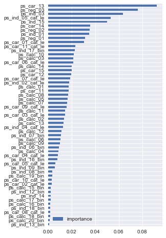

```python
model.feature_names = full_vars
feature_importance = pd.DataFrame.from_dict(model.get_fscore(), orient='index')
feature_importance.columns = ['importance']
feature_importance.importance = feature_importance.importance/ feature_importance.importance.sum()
feature_importance.sort_values(by='importance').plot(kind='barh',figsize=(4,8))
```

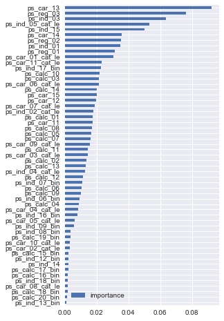

```python
feature_importance.sort_values(by='importance').plot(kind='barh',figsize=(4,8))
```

### -1 as missing value

As mentioned before, XGBoost has a graceful way of dealing with missing values: you just need to set the parameter "missing", which by default is None but we'll want to set it to -1 for this case.

```python
xgb_params = {
    'max_depth': 6,
    'min_child_weight': 1,
    'subsample': 1,
    'colsample_bytree': 1,
    'gamma': 0,
    'objective': 'binary:logistic',
    'eta': 0.1,
    'seed': 1234}

print(xgb_params)

cv_results = xgb.cv(xgb_params, xgb.DMatrix(train_x, label=train_y.reshape(train_x.shape[0], 1), missing=-1),
                    num_boost_round=1000000,
                    nfold=5,
                    feval=gini_xgb, # custom evaluation metric
                    maximize=True,
                    stratified=True,
                    shuffle=True,
                    verbose_eval=50,
                    seed=1234,
                    early_stopping_rounds=50)

best_xgb_score = cv_results['test-gini-mean'].max()
best_xgb_iteration = len(cv_results)

print('best score:', best_xgb_score, 'best iterations:', best_xgb_iteration)
```

```
{'subsample': 1, 'eta': 0.1, 'colsample_bytree': 1, 'gamma': 0, 'objective': 'binary:logistic', 'seed': 1234, 'max_depth': 6, 'min_child_weight': 1}
('best score:', 0.27654279999999998, 'best iterations:', 92)
```

```python
model = xgb.train(xgb_params,
                  xgb.DMatrix(train_x, label=train_y.reshape(train_x.shape[0], 1), missing=-1),
                  num_boost_round=best_xgb_iteration
                 )

preds = model.predict(xgb.DMatrix(test_x))

sub_df = pd.DataFrame({'id': ids, 'target': preds})
sub_df.to_csv("sub_xgb_num_le_-1_as_missing.csv", index=False)
```

## numerical features + one-hot-encoded categorical features

```python
full_vars = num_vars
train_x = full_data[full_vars].fillna(-1)[:train_size].values
train_y = full_data['target'][:train_size].values
test_x = full_data[full_vars].fillna(-1)[train_size:].values
ids = full_data[train_size:].id.values

# concatenate dense features with sparse features
train_x = sparse.hstack([train_x,
                         OHE_sparse[:train_size]]
                       ).tocsr()

test_x = sparse.hstack([test_x,
                         OHE_sparse[train_size:]]
                       ).tocsr()

train_y = full_data['target'][:train_size].values

print ('train data size:', train_x.shape, 'test data size:', test_x.shape)
```

```
('train data size:', (595212, 227), 'test data size:', (892816, 227))
```

```python
xgb_params = {
    'max_depth': 6,
    'min_child_weight': 1,
    'subsample': 1,
    'colsample_bytree': 1,
    'gamma': 0,
    'objective': 'binary:logistic',
    'eta': 0.1,
    'seed': 1234}

print(xgb_params)

cv_results = xgb.cv(xgb_params, xgb.DMatrix(train_x, label=train_y.reshape(train_x.shape[0], 1)),
                    num_boost_round=1000000,
                    nfold=5,
                    feval=gini_xgb, # custom evaluation metric
                    maximize=True,
                    stratified=True,
                    shuffle=True,
                    verbose_eval=50,
                    seed=1234,
                    early_stopping_rounds=50)

best_xgb_score = cv_results['test-gini-mean'].max()
best_xgb_iteration = len(cv_results)

print('best score:', best_xgb_score, 'best iterations:', best_xgb_iteration)
```

```
{'subsample': 1, 'eta': 0.1, 'colsample_bytree': 1, 'gamma': 0, 'objective': 'binary:logistic', 'seed': 1234, 'max_depth': 6, 'min_child_weight': 1}
('best score:', 0.27703080000000002, 'best iterations:', 82)
```

```python
model = xgb.train(xgb_params,
                  xgb.DMatrix(train_x, label=train_y.reshape(train_x.shape[0], 1)),
                  num_boost_round=best_xgb_iteration
                 )

preds = model.predict(xgb.DMatrix(test_x))

sub_df = pd.DataFrame({'id': ids, 'target': preds})
sub_df.to_csv("sub_xgb_num_ohe.csv", index=False)
```

### -1 as missing value

```python
xgb_params = {
    'max_depth': 6,
    'min_child_weight': 1,
    'subsample': 1,
    'colsample_bytree': 1,
    'gamma': 0,
    'objective': 'binary:logistic',
    'eta': 0.1,
    'seed': 1234}

print(xgb_params)

cv_results = xgb.cv(xgb_params, xgb.DMatrix(train_x, label=train_y.reshape(train_x.shape[0], 1), missing=-1),
                    num_boost_round=1000000,
                    nfold=5,
                    feval=gini_xgb, # custom evaluation metric
                    maximize=True,
                    stratified=True,
                    shuffle=True,
                    verbose_eval=50,
                    seed=1234,
                    early_stopping_rounds=50)

best_xgb_score = cv_results['test-gini-mean'].max()
best_xgb_iteration = len(cv_results)

print('best score:', best_xgb_score, 'best iterations:', best_xgb_iteration)
```

```
{'subsample': 1, 'eta': 0.1, 'colsample_bytree': 1, 'gamma': 0, 'objective': 'binary:logistic', 'seed': 1234, 'max_depth': 6, 'min_child_weight': 1}
('best score:', 0.27703080000000002, 'best iterations:', 82)
```

```python
model = xgb.train(xgb_params,
                  xgb.DMatrix(train_x, label=train_y.reshape(train_x.shape[0], 1), missing=-1),
                  num_boost_round=best_xgb_iteration
                 )

preds = model.predict(xgb.DMatrix(test_x))

sub_df = pd.DataFrame({'id': ids, 'target': preds})
sub_df.to_csv("sub_xgb_num_ohe_-1_as_missing.csv", index=False)
```

## Exclude cal features

```python
calc_vars = [var for var in full_data.columns if 'calc' in var]
print (calc_vars)

full_vars = num_vars

for calc_var in calc_vars:
    if calc_var in full_vars:
        full_vars.remove(calc_var)


train_x = full_data[full_vars].fillna(-1)[:train_size].values
train_y = full_data['target'][:train_size].values
test_x = full_data[full_vars].fillna(-1)[train_size:].values
ids = full_data[train_size:].id.values

# concatenate dense features with sparse features
train_x = sparse.hstack([train_x,
                         OHE_sparse[:train_size]]
                       ).tocsr()

test_x = sparse.hstack([test_x,
                         OHE_sparse[train_size:]]
                       ).tocsr()

train_y = full_data['target'][:train_size].values

print ('train data size:', train_x.shape, 'test data size:', test_x.shape)
```

```
['ps_calc_01', 'ps_calc_02', 'ps_calc_03', 'ps_calc_04', 'ps_calc_05', 'ps_calc_06', 'ps_calc_07', 'ps_calc_08', 'ps_calc_09', 'ps_calc_10', 'ps_calc_11', 'ps_calc_12', 'ps_calc_13', 'ps_calc_14', 'ps_calc_15_bin', 'ps_calc_16_bin', 'ps_calc_17_bin', 'ps_calc_18_bin', 'ps_calc_19_bin', 'ps_calc_20_b…
('train data size:', (595212, 207), 'test data size:', (892816, 207))
```

```python
xgb_params = {
    'max_depth': 6,
    'min_child_weight': 1,
    'subsample': 1,
    'colsample_bytree': 1,
    'gamma': 0,
    'objective': 'binary:logistic',
    'eta': 0.1,
    'seed': 1234}

print(xgb_params)

cv_results = xgb.cv(xgb_params, xgb.DMatrix(train_x, label=train_y.reshape(train_x.shape[0], 1)),
                    num_boost_round=1000000,
                    nfold=5,
                    feval=gini_xgb, # custom evaluation metric
                    maximize=True,
                    stratified=True,
                    shuffle=True,
                    verbose_eval=50,
                    seed=1234,
                    early_stopping_rounds=50)

best_xgb_score = cv_results['test-gini-mean'].max()
best_xgb_iteration = len(cv_results)

print('best score:', best_xgb_score, 'best iterations:', best_xgb_iteration)
```

```
{'subsample': 1, 'eta': 0.1, 'colsample_bytree': 1, 'gamma': 0, 'objective': 'binary:logistic', 'seed': 1234, 'max_depth': 6, 'min_child_weight': 1}
('best score:', 0.27933240000000004, 'best iterations:', 109)
```

```python
model = xgb.train(xgb_params,
                  xgb.DMatrix(train_x, label=train_y.reshape(train_x.shape[0], 1)),
                  num_boost_round=best_xgb_iteration
                 )

preds = model.predict(xgb.DMatrix(test_x))

sub_df = pd.DataFrame({'id': ids, 'target': preds})
sub_df.to_csv("sub_xgb_num_ohe_cal_excluded.csv", index=False)
```

# Put together

Let's do a quick ensemble by averaging all of the submissions created above

```python
sub_1 = pd.read_csv('sub_xgb_num_le.csv')
sub_2 = pd.read_csv('sub_xgb_num_le_-1_as_missing.csv')
sub_3 = pd.read_csv('sub_xgb_num_ohe.csv')
sub_4 = pd.read_csv('sub_xgb_num_ohe_-1_as_missing.csv')
sub_5 = pd.read_csv('sub_xgb_num_ohe_cal_excluded.csv')
```

```python
ensemble_preds = (sub_1.target + sub_2.target + sub_3.target + sub_4.target + sub_5.target)/5
sub_df = pd.DataFrame({'id': ids, 'target': ensemble_preds})
sub_df.to_csv("sub_xgb_quick_ensemble.csv", index=False)
```

# Conclusions

Feature engineering is the key, if not the most important, to the success of a data science projecct including Kaggle competition. It requires a data scientist to have excellent knowledge of Machine Learning algorithms, good sense of business, programming skills and, last but not least, hacker spirits.

In this week's lecture we've learnt how to:

# Recommended Kaggle posts:

- [Porto Seguro EDA](https://www.kaggle.com/vmathur/porto-seguro-eda)
- [Steering Wheel of Fortune - Porto Seguro EDA](https://www.kaggle.com/headsortails/steering-wheel-of-fortune-porto-seguro-eda/notebook)
- [Features? We don't need no stinking features!](https://www.kaggle.com/tilii7/features-we-don-t-need-no-stinking-features)
- [Noise analysis of Porto Seguro's features](https://www.kaggle.com/ogrellier/noise-analysis-of-porto-seguro-s-features)

# Additional readings

- [Applied Predictive Modeling - Chapter 3 Data Pre-Processing](http://appliedpredictivemodeling.com/toc/)
- [机器学习特征工程实用技巧大全](https://zhuanlan.zhihu.com/p/26444240)
- [Discover Feature Engineering](http://machinelearningmastery.com/discover-feature-engineering-how-to-engineer-features-and-how-to-get-good-at-it/)
- [Selecting good features – Part IV: stability selection, RFE and everything side by side](http://blog.datadive.net/selecting-good-features-part-iv-stability-selection-rfe-and-everything-side-by-side/)

# Assignments

1. Run this notebook and make submissions
2. Experiment whatever feature engineering you could think of and see how they perform

# Model tuning

## 1. XGBoost

### Manual tuning

#### max_depth

```python
scores = []
for max_depth in [5, 6, 7, 8, 9, 10]:

    params = dict()
    params['objective'] = 'binary:logistic'
#     params['num_class'] = 3
    params['eta'] = 0.1
    params['max_depth'] = max_depth
    params['min_child_weight'] = 1
    params['colsample_bytree'] = 1
    params['subsample'] = 1
    params['gamma'] = 0
    params['seed'] = 1234

    cv_results = xgb.cv(params, xgb.DMatrix(train_x, label=train_y.reshape(train_x.shape[0], 1), missing=-1),
                        num_boost_round=1000000,
                        nfold=5,
                        #            metrics={'mlogloss'},
                        feval=gini_xgb, maximize=True,
                        stratified=True,
                        shuffle=True,
                        seed=1234,
                        early_stopping_rounds=10)
    best_iteration = len(cv_results)
    best_score = cv_results['test-gini-mean'].max()
    print(max_depth, best_score, best_iteration)
    scores.append([best_score, params['eta'], params['max_depth'], params['min_child_weight'],
                   params['colsample_bytree'], params['subsample'], params['gamma'], best_iteration])

scores = pd.DataFrame(scores, columns=['score', 'eta', 'max_depth', 'min_child_weight',
                                       'colsample_bytree', 'subsample', 'gamma', 'best_iteration'])
best_max_depth = scores.sort_values(by='score', ascending=False)[
    'max_depth'].values[0]
print('best max_depth is', best_max_depth)
```

```
(5, 0.28094840000000004, 100)
(6, 0.27933240000000004, 109)
(7, 0.27782639999999997, 78)
(8, 0.27458539999999998, 66)
(9, 0.27010780000000001, 63)
(10, 0.26402739999999997, 56)
('best max_depth is', 5)
```

#### min_child_weight

```python
scores = []
for min_child_weight in [1, 10, 50, 100]:

    params = dict()
    params['objective'] = 'binary:logistic'
#     params['num_class'] = 3
    params['eta'] = 0.1
    params['max_depth'] = best_max_depth
    params['min_child_weight'] = min_child_weight
    params['colsample_bytree'] = 1
    params['subsample'] = 1
    params['gamma'] = 0
    params['seed'] = 1234

    cv_results = xgb.cv(params, xgb.DMatrix(train_x, label=train_y.reshape(train_x.shape[0], 1), missing=-1),
                        num_boost_round=1000000,
                        nfold=5,
                        #            metrics={'mlogloss'},
                        feval=gini_xgb, maximize=True,
                        stratified=True,
                        shuffle=True,
                        seed=1234,
                        early_stopping_rounds=10)
    best_iteration = len(cv_results)
    best_score = cv_results['test-gini-mean'].max()
    print(min_child_weight, best_score, best_iteration)
    scores.append([best_score, params['eta'], params['max_depth'], params['min_child_weight'],
                   params['colsample_bytree'], params['subsample'], params['gamma'], best_iteration])

scores = pd.DataFrame(scores, columns=['score', 'eta', 'max_depth', 'min_child_weight',
                                       'colsample_bytree', 'subsample', 'gamma', 'best_iteration'])
best_min_child_weight = scores.sort_values(by='score', ascending=False)[
    'min_child_weight'].values[0]
print('best min_child_weight is', best_min_child_weight)
```

```
(1, 0.28094840000000004, 100)
(10, 0.2819218, 140)
(50, 0.28372180000000002, 135)
(100, 0.28470420000000002, 187)
('best min_child_weight is', 100)
```

#### colsample_bytree

```python
scores = []
for colsample_bytree in [0.1, 0.3, 0.5, 0.7, 0.9]:

    params = dict()
    params['objective'] = 'binary:logistic'
#     params['num_class'] = 3
    params['eta'] = 0.1
    params['max_depth'] = best_max_depth
    params['min_child_weight'] = best_min_child_weight
    params['colsample_bytree'] = colsample_bytree
    params['subsample'] = 1
    params['gamma'] = 0
    params['seed'] = 1234

    cv_results = xgb.cv(params, xgb.DMatrix(train_x, label=train_y.reshape(train_x.shape[0], 1), missing=-1),
                        num_boost_round=1000000,
                        nfold=5,
                        #            metrics={'mlogloss'},
                        feval=gini_xgb, maximize=True,
                        stratified=True,
                        shuffle=True,
                        seed=1234,
                        early_stopping_rounds=10)
    best_iteration = len(cv_results)
    best_score = cv_results['test-gini-mean'].min()
    print(colsample_bytree, best_score, best_iteration)
    scores.append([best_score, params['eta'], params['max_depth'], params['min_child_weight'],
                   params['colsample_bytree'], params['subsample'], params['gamma'], best_iteration])

scores = pd.DataFrame(scores, columns=['score', 'eta', 'max_depth', 'min_child_weight',
                                       'colsample_bytree', 'subsample', 'gamma', 'best_iteration'])
best_colsample_bytree = scores.sort_values(by='score', ascending=False)[
    'colsample_bytree'].values[0]
print('best colsample_bytree is', best_colsample_bytree)
```

```
(0.1, 0.12864059999999999, 258)
(0.3, 0.17649559999999997, 139)
(0.5, 0.17817499999999997, 200)
(0.7, 0.18460219999999999, 152)
(0.9, 0.2007536, 185)
('best colsample_bytree is', 0.90000000000000002)
```

#### subsample

```python
scores = []
for subsample in [0.1, 0.3, 0.5, 0.7, 0.9]:

    params = dict()
    params['objective'] = 'binary:logistic'
#     params['num_class'] = 3
    params['eta'] = 0.1
    params['max_depth'] = best_max_depth
    params['min_child_weight'] = best_min_child_weight
    params['colsample_bytree'] = best_colsample_bytree
    params['subsample'] = subsample
    params['gamma'] = 0
    params['seed'] = 1234

    cv_results = xgb.cv(params, xgb.DMatrix(train_x, label=train_y.reshape(train_x.shape[0], 1), missing=-1),
                        num_boost_round=1000000,
                        nfold=5,
                        #            metrics={'mlogloss'},
                        feval=gini_xgb, maximize=True,
                        stratified=True,
                        shuffle=True,
                        seed=1234,
                        early_stopping_rounds=10)
    best_iteration = len(cv_results)
    best_score = cv_results['test-gini-mean'].max()
    print(subsample, best_score, best_iteration)
    scores.append([best_score, params['eta'], params['max_depth'], params['min_child_weight'],
                   params['colsample_bytree'], params['subsample'], params['gamma'], best_iteration])

scores = pd.DataFrame(scores, columns=['score', 'eta', 'max_depth', 'min_child_weight',
                                       'colsample_bytree', 'subsample', 'gamma', 'best_iteration'])
best_subsample = scores.sort_values(by='score', ascending=False)[
    'subsample'].values[0]
print('best subsample is', best_subsample)
```

```
(0.1, 0.27150100000000005, 117)
(0.3, 0.28239199999999998, 135)
(0.5, 0.28449360000000001, 133)
(0.7, 0.28551460000000006, 182)
(0.9, 0.28519139999999998, 161)
('best subsample is', 0.69999999999999996)
```

#### gamma

```python
scores = []
for gamma in [0, 0.5, 1, 1.5, 2]:

    params = dict()
    params['objective'] = 'binary:logistic'
#     params['num_class'] = 3
    params['eta'] = 0.1
    params['max_depth'] = best_max_depth
    params['min_child_weight'] = best_min_child_weight
    params['colsample_bytree'] = best_colsample_bytree
    params['subsample'] = best_subsample
    params['gamma'] = gamma
    params['seed'] = 1234

    cv_results = xgb.cv(params, xgb.DMatrix(train_x, label=train_y.reshape(train_x.shape[0], 1), missing=-1),
                        num_boost_round=1000000,
                        nfold=5,
                        #            metrics={'mlogloss'},
                        feval=gini_xgb, maximize=True,
                        stratified=True,
                        shuffle=True,
                        seed=1234,
                        early_stopping_rounds=10)
    best_iteration = len(cv_results)
    best_score = cv_results['test-gini-mean'].max()
    print(gamma, best_score, best_iteration)
    scores.append([best_score, params['eta'], params['max_depth'], params['min_child_weight'],
                   params['colsample_bytree'], params['subsample'], params['gamma'], best_iteration])

scores = pd.DataFrame(scores, columns=['score', 'eta', 'max_depth', 'min_child_weight',
                                       'colsample_bytree', 'subsample', 'gamma', 'best_iteration'])
best_gamma = scores.sort_values(by='score', ascending=False)['gamma'].values[0]
print('best gamma is', best_gamma)
```

```
(0, 0.28551460000000006, 182)
(0.5, 0.28394140000000007, 137)
(1, 0.28428179999999997, 138)
(1.5, 0.28521859999999999, 138)
(2, 0.28444100000000005, 187)
('best gamma is', 0.0)
```

```python
print(best_max_depth, best_min_child_weight,
      best_colsample_bytree, best_subsample, best_gamma)

scores.sort_values(by='score',ascending=False)
```

```
(5, 100, 0.90000000000000002, 0.69999999999999996, 0.0)
```

|  | score | eta | max_depth | min_child_weight | colsample_bytree | subsample | gamma | best_iteration |
| --- | --- | --- | --- | --- | --- | --- | --- | --- |
| 0 | 0.285515 | 0.1 | 5 | 100 | 0.9 | 0.7 | 0.0 | 182 |
| 3 | 0.285219 | 0.1 | 5 | 100 | 0.9 | 0.7 | 1.5 | 138 |
| 4 | 0.284441 | 0.1 | 5 | 100 | 0.9 | 0.7 | 2.0 | 187 |
| 2 | 0.284282 | 0.1 | 5 | 100 | 0.9 | 0.7 | 1.0 | 138 |
| 1 | 0.283941 | 0.1 | 5 | 100 | 0.9 | 0.7 | 0.5 | 137 |

### Auto Tuning

```python
xgtrain = xgb.DMatrix(train_x, label=train_y.reshape(train_x.shape[0], 1))


def xgb_evaluate(min_child_weight,
                 colsample_bytree,
                 max_depth,
                 subsample,
                 gamma):
    params = dict()
    params['objective'] = 'binary:logistic'
#     params['num_class'] = 3
    params['eta'] = 0.1
    params['max_depth'] = int(max_depth)
    params['min_child_weight'] = int(min_child_weight)
    params['colsample_bytree'] = colsample_bytree
    params['subsample'] = subsample
    params['gamma'] = gamma
    params['verbose_eval'] = True

    cv_results = xgb.cv(params, xgb.DMatrix(train_x, label=train_y.reshape(train_x.shape[0], 1), missing=-1),
                        num_boost_round=1000000,
                        nfold=5,
                        #            metrics={'mlogloss'},
                        feval=gini_xgb, maximize=True,
                        stratified=True,
                        shuffle=True,
                        seed=1234,
                        early_stopping_rounds=10)

    return cv_results['test-gini-mean'].max()


xgb_BO = BayesianOptimization(xgb_evaluate,
                              {'max_depth': (3, 6),
                               'min_child_weight': (60, 120),
                               'colsample_bytree': (0.7, 1.0),
                               'subsample': (0.6, 0.8),
                               'gamma': (0, 0.5)
                               }
                              )

xgb_BO.maximize(init_points=5, n_iter=40)
```

```
Initialization
---------------------------------------------------------------------------------------------------------------
 Step |   Time |      Value |   colsample_bytree |     gamma |   max_depth |   min_child_weight |   subsample |
    1 | 22m07s |    0.28464 |             0.7066 |    0.3130 |      5.8156 |           112.1409 |      0.7665 |
    2 | 22m21s |    0.28578 |             0.8973 |    0.0926 |      5.0373 |            88.7600 |      0.6983 |
    3 | 18m52s |    0.28400 |             0.8844 |    0.3899 |      3.0926 |            97.5710 |      0.7764 |
    4 | 16m39s |    0.28417 |             0.9328 |    0.0511 |      5.0191 |           118.4849 |      0.7289 |
    5 | 19m23s |    0.28424 |             0.7364 |    0.3539 |      3.3598 |            60.1405 |      0.6758 |
```

[output not shown]

```
   0.28493 |             0.9920 |    0.0282 |      5.9233 |           103.2631 |      0.6038 |
    9 | 24m14s |    0.28405 |             0.9993 |    0.4674 |      5.9897 |            88.3914 |      0.6328 |
   10 | 15m17s |    0.28422 |             0.7116 |    0.0592 |      5.9478 |            60.2227 |      0.7904 |
   11 | 17m48s |    0.28552 |             0.7226 |    0.0338 |      5.7669 |            94.6964
```

```
 |      0.7992 |
   12 | 21m07s |    0.28380 |             0.9851 |    0.0092 |      3.4359 |            78.1793 |      0.7944 |
   13 | 16m57s |    0.28386 |             0.7013 |    0.0163 |      3.0170 |           112.5304 |      0.6078 |
```

[output not shown]

[output not shown]

```
 |    0.28518 |             0.9562 |    0.0263 |      3.2125 |            60.0375 |      0.7211 |
   16 | 18m42s |    0.28597 |             0.9638 |    0.0003 |      5.9875 |           112.7902 |      0.7748
```

```
   17 | 19m34s |    0.28531 |             0.8426 |    0.0273 |      5.9595 |            85.6149 |      0.7985 |
```

[output not shown]

```
   0.28450 |             0.7265 |    0.0210 |      5.9757 |           118.7172 |      0.6472 |
   19 | 22m27s |    0.28584 |             0.9830 |    0.0141 |      3.1028 |            91.6178 |      0.6905 |
   20 | 19m55s |    0.28516 |             0.7767 |    0.0163 |      4.9564 |           107.3631 |      0.7986 |
   21 | 21m46s |    0.28535 |             0.9952 |    0.0090 |      5.4721 |            90.8314 |      0.7805 |
   22 | 21m28s |    0.28409 |             0.9977 |    0.2881 |      5.9536 |            60.1094 |      0.6044 |
   23 |
```

```
16m02s |    0.28381 |             0.7163 |    0.0044 |      3.0264 |            88.8532 |      0.6841 |
   24 | 23m50s |    0.28596 |             0.9574 |    0.0070 |      4.3362 |            96.4155 |      0.6137 |
   25 | 19m43s |    0.28498 |             0.9948 |    0.4229 |      4.2813 |            63.1958 |      0.7958 |
   26 | 25m24s |    0.28482
```

```
 |             0.8172 |    0.0129 |      3.0861 |           119.9257 |      0.7587 |
   27 | 19m34s |    0.28383 |             0.9990 |    0.4488 |      3.8470 |            71.9469 |      0.7950 |
   28 | 22m39s |    0.28507 |             0.7015 |    0.0137 |      4.1427 |           117.3053 |      0.7976 |
   29 | 17m33s |    0.28314 |             0.7055 |    0.0060 |      3.6692 |            93.5630 |      0.6307 |
```

```
   30 | 26m43s |    0.28573 |             0.9844 |    0.4945 |      4.7044 |            82.8590 |      0.7989 |
   31 | 17m33s |    0.28439 |             0.9952 |    0.0009 |      5.7632 |            98.7095 |      0.7847 |
   32 | 21m46s |    0.28366 |
```

```
            0.9928 |    0.0275 |      3.1558 |           103.6154 |      0.7891 |
   33 | 20m25s |    0.28486 |             0.9970 |    0.0081 |      3.4058 |            84.8961 |      0.6394 |
```

```
   34 | 17m50s |    0.28408 |             0.9864 |    0.0644 |      5.8997 |            80.4323 |      0.7772 |
   35 | 23m57s |    0.28553 |
```

```
            0.9879 |    0.4585 |      4.9898 |            95.2231 |      0.7930 |
   36 | 13m33s |    0.28307 |             0.7532 |    0.0008 |      5.1734 |            62.7265 |      0.6042 |
```

[output not shown]

[output not shown]

```
 |    0.28421 |             0.9420 |    0.0416 |      5.8523 |           109.1630 |      0.6017 |
   40 | 20m43s |    0.28455 |             0.9906 |    0.4602 |      3.7903 |            86.4541 |      0.7877 |
   41 | 19m19s |
```

```
   0.28561 |             0.7666 |    0.4777 |      5.9841 |           119.9226 |      0.7533 |
   42 | 15m52s |    0.28412 |             0.7784 |    0.4861 |      5.8502 |            67.0294 |      0.7959 |
   43 | 19m55s |    0.28523 |             0.9916 |    0.1086 |      5.9887 |           105.7445 |      0.7876 |
   44 | 17m01s |
```

```
   0.28348 |             0.7001 |    0.0106 |      5.7785 |            72.4416 |      0.7651 |
   45 | 27m08s |    0.28523 |             0.9778 |    0.1323 |      3.0434 |           109.4978 |      0.7920 |
```

#### Show tuning results

```python
xgb_BO.res
```

```
{'all': {'params': [{'colsample_bytree': 0.9999971141594497,
    'gamma': 0.066076042755743802,
    'max_depth': 5.9341254396701633,
    'min_child_weight': 69.502211467941905,
    'subsample': 0.78418283983515902},
   {'colsample_bytree': 0.71414390576023223,
    'gamma': 0.0026982722149443417,
    'max_depth': 5.5713535657818092,
    'min_child_weight': 76.916360225848322,
    'subsample': 0.60676230032380474},
   {'colsample_bytree': 0.99195875776652231,
    'gamma': 0.028237074999152789,
    'max_depth': 5.9233145414215738,
    'min_child_weight': 103.26313933047523,
    'subsample': 0.60381784669952865},
   {'colsample_bytree': 0.9992600193693576,
    'gamma': 0.46742799866729101,
    'max_depth': 5.9897168538955965,
    'min_child_weight': 88.391365135735384,
    'subsample': 0.63280609605226557},
   {'colsample_bytree': 0.71162782147755466,
    'gamma': 0.059206369581958129,
    'max_depth': 5.9477637929223244,
    'min_child_weight': 60.22265071931799,
    'subsample': 0.79041745291613486},
   {'colsample_bytree': 0.7226146810659273,
    'gamma': 0.03375369863968769,
    'max_depth': 5.7669219932638729,
    'min_child_weight': 94.696401472070164,
    'subsample': 0.79920207739392501},
   {'colsample_bytree': 0.9850550835915306,
    'gamma': 0.0092408162798901516,
    'max_depth': 3.4359086939413288,
    'min_child_weight': 78.179337753931776,
    'subsample': 0.79444961199406083},
   {'colsample_bytree': 0.70133590275001645,
    'gamma': 0.016346870382002943,
    'max_depth': 3.0170053104116814,
    'min_child_weight': 112.53042012384645,
    'subsample': 0.60783399549766559},
```

[output cut: 191 more lines]

```
   0.2850512,
   0.28326299999999993,
   0.2842056,
   0.28455339999999996,
   0.28561160000000002,
   0.28411720000000001,
   0.2852266,
   0.28347820000000001,
   0.28522879999999995]},
 'max': {'max_params': {'colsample_bytree': 0.96377702312996882,
   'gamma': 0.0003257048716885369,
   'max_depth': 5.9874594178429046,
   'min_child_weight': 112.7902177141973,
   'subsample': 0.77477195833560308},
  'max_val': 0.28597020000000001}}
```

```python
xgb_BO_scores = pd.DataFrame(xgb_BO.res['all']['params'])
xgb_BO_scores['score'] = pd.DataFrame(xgb_BO.res['all']['values'])
xgb_BO_scores = xgb_BO_scores.sort_values(by='score',ascending=False)
xgb_BO_scores.head()
```

|  | colsample_bytree | gamma | max_depth | min_child_weight | subsample | score |
| --- | --- | --- | --- | --- | --- | --- |
| 10 | 0.963777 | 0.000326 | 5.987459 | 112.790218 | 0.774772 | 0.285970 |
| 18 | 0.957393 | 0.006958 | 4.336177 | 96.415500 | 0.613684 | 0.285959 |
| 13 | 0.983024 | 0.014053 | 3.102784 | 91.617761 | 0.690495 | 0.285843 |
| 24 | 0.984386 | 0.494495 | 4.704437 | 82.858973 | 0.798895 | 0.285729 |
| 35 | 0.766584 | 0.477684 | 5.984062 | 119.922616 | 0.753306 | 0.285612 |

#### Plot scores vs parameters

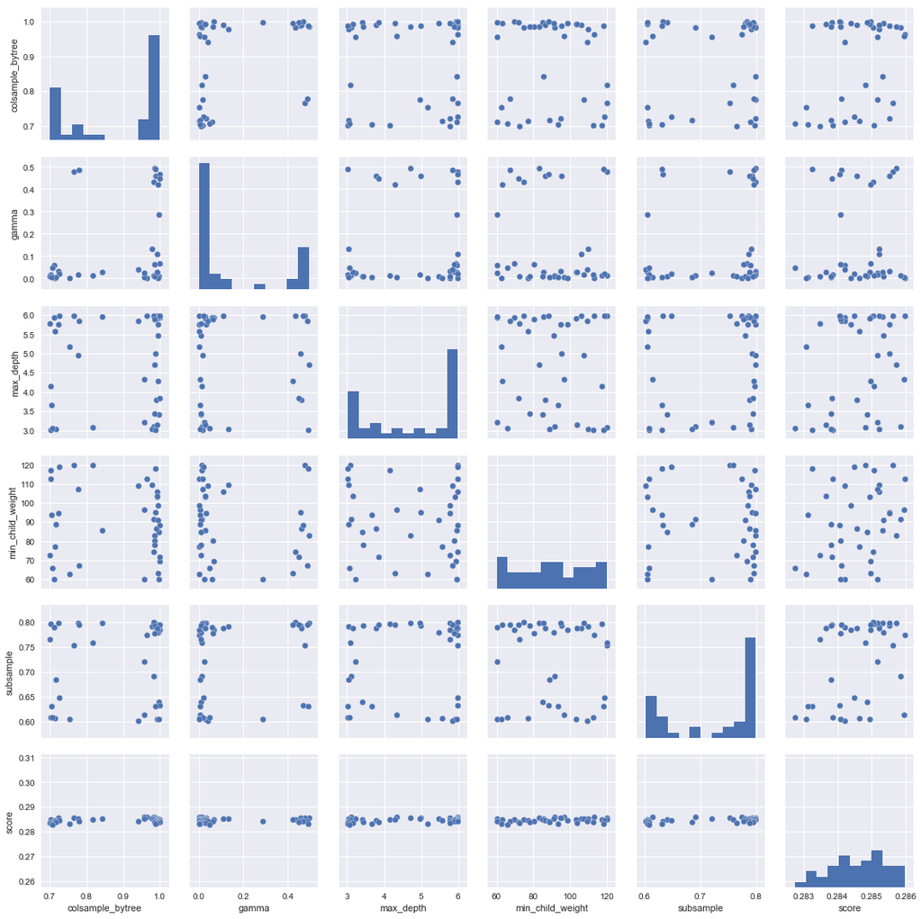

```python
sns.pairplot(xgb_BO_scores)
```

### Train the model with smaller learning rate

```python
xgb_params = xgb_BO_scores.iloc[0].to_dict()
xgb_params['objective'] = 'binary:logistic'
xgb_params['eta'] = 0.01  # Smaller

xgb_params['max_depth'] = int(xgb_params['max_depth'])
xgb_params['min_child_weight'] = int(xgb_params['min_child_weight'])
xgb_params['subsample'] = xgb_params['subsample']
xgb_params['colsample_bytree'] = xgb_params['colsample_bytree']
xgb_params['gamma'] = xgb_params['gamma']
xgb_params['seed'] = 1234

cv_results = xgb.cv(xgb_params, xgb.DMatrix(train_x, label=train_y.reshape(train_x.shape[0], 1), missing=-1),
                    num_boost_round=1000000,
                    nfold=5,
                    feval=gini_xgb, maximize=True,
                    stratified=True,
                    shuffle=True,
                    seed=1234,
                    early_stopping_rounds=10)

best_iteration = len(cv_results)
best_score = cv_results['test-gini-mean'].max()
print(best_score, best_iteration)
```

```
(0.28784219999999999, 1614)
```

```python
best_iteration
```

```
1614
```

```python
model = xgb.train(xgb_params,
                  xgb.DMatrix(train_x, label=train_y.reshape(
                      train_x.shape[0], 1), missing=-1),
                  num_boost_round=best_iteration
                  )

preds = model.predict(xgb.DMatrix(test_x))

sub_df = pd.DataFrame({'id': ids, 'target': preds})
sub_df.to_csv("sub_xgb_tuned.csv", index=False)
```

## 2.LightGBM

### Manual tuning

#### max_bin

```python
scores = []
for max_bin in [100, 255, 400, 600, 800, 1000]:

    params = dict()
    params['objective'] = 'binary'
    params['learning_rate'] = 0.05
    params['max_bin'] = max_bin

    print(max_bin)

    cv_results = lgb.cv(params,
                        lgb.Dataset(train_x, train_y, max_bin=max_bin),
                        num_boost_round=1000000,
                        nfold=5,
                        early_stopping_rounds=50,
                        feval=gini_lgb,
                        stratified=True,
                        shuffle=True,
                        verbose_eval=100
                        )
    cv_results = pd.DataFrame(cv_results)
    best_iteration = len(cv_results)
    best_score = cv_results['gini-mean'].max()
    print(max_bin, best_iteration, best_score)
    scores.append([max_bin, best_iteration, best_score])

scores = pd.DataFrame(scores, columns=['max_bin', 'iteration', 'score'])
best_max_bin = scores.sort_values(by='score', ascending=False)[
    'max_bin'].values[0]
print('best max_bin is', best_max_bin)
```

```
100
[100]	cv_agg's gini: 0.273023 + 0.0125793
[200]	cv_agg's gini: 0.280231 + 0.011553
(100, 223, 0.28046673401783506)
255
[100]	cv_agg's gini: 0.272644 + 0.0134858
[200]	cv_agg's gini: 0.280776 + 0.0117713
(255, 170, 0.28105984327015038)
400
[100]	cv_agg's gini: 0.272948 + 0.0131354
[200]	cv_agg's gini: 0.279755 + 0.0115309
(400, 211, 0.27990932771228572)
600
[100]	cv_agg's gini: 0.272665 + 0.0134226
[200]	cv_agg's gini: 0.280374 + 0.0124065
(600, 172, 0.28053786442418716)
800
[100]	cv_agg's gini: 0.272488 + 0.0133795
[200]	cv_agg's gini: 0.280235 + 0.0118085
(800, 209, 0.28044320294208325)
1000
[100]	cv_agg's gini: 0.273059 + 0.0125486
[200]	cv_agg's gini: 0.280958 + 0.0115153
(1000, 182, 0.28120563100279872)
('best max_bin is', 1000)
```

#### num_leaves

```python
scores = []
for num_leaves in [3, 10, 30, 100, 300, 1000]:

    params = dict()
    params['objective'] = 'binary'
    params['learning_rate'] = 0.05
    params['max_bin'] = best_max_bin
    params['num_leaves'] = num_leaves

    print(num_leaves)

    cv_results = lgb.cv(params,
                        lgb.Dataset(train_x, train_y, max_bin=best_max_bin),
                        num_boost_round=1000000,
                        nfold=5,
                        early_stopping_rounds=50,
                        feval=gini_lgb,
                        stratified=True,
                        shuffle=True,
                        verbose_eval=100
                        )
    cv_results = pd.DataFrame(cv_results)
    best_iteration = len(cv_results)
    best_score = cv_results['gini-mean'].max()
    print(num_leaves, best_score, best_iteration)
    scores.append([num_leaves, best_iteration, best_score])

scores = pd.DataFrame(scores, columns=['num_leaves', 'iteration', 'score'])
best_num_leaves = scores.sort_values(by='score', ascending=False)[
    'num_leaves'].values[0]
print('best num_leaves is', best_num_leaves)
```

```
3
[100]	cv_agg's gini: 0.241533 + 0.0146355
[200]	cv_agg's gini: 0.260397 + 0.0145952
[300]	cv_agg's gini: 0.2669 + 0.0139285
[400]	cv_agg's gini: 0.270378 + 0.0132966
[500]	cv_agg's gini: 0.272701 + 0.0127816
[600]	cv_agg's gini: 0.274288 + 0.0124661
[700]	cv_agg's gini: 0.275392 + 0.0122985
[800]	cv_agg's gini: 0.276205 + 0.0123388
[900]	cv_agg's gini: 0.277022 + 0.0123529
[1000]	cv_agg's gini: 0.277688 + 0.0123589
[1100]	cv_agg's gini: 0.278188 + 0.0122068
[1200]	cv_agg's gini: 0.278631 + 0.0121955
[1300]	cv_agg's gini: 0.279064 + 0.0122255
[1400]	cv_agg's gini: 0.279355 + 0.0122246
[1500]	cv_agg's gini: 0.279544 + 0.0121935
[1600]	cv_agg's gini: 0.279736 + 0.0122782
[1700]	cv_agg's gini: 0.27981 + 0.0123666
[1800]	cv_agg's gini: 0.27997 + 0.0125068
[1900]	cv_agg's gini: 0.279978 + 0.0124685
(3, 0.28006323488605206, 1869)
10
[100]	cv_agg's gini: 0.265035 + 0.014386
[200]	cv_agg's gini: 0.277396 + 0.0125764
[300]	cv_agg's gini: 0.279675 + 0.0126527
[400]	cv_agg's gini: 0.280409 + 0.0123886
(10, 0.28057280470858553, 426)
30
[100]	cv_agg's gini: 0.272484 + 0.0129811
[200]	cv_agg's gini: 0.280519 + 0.0114695
(30, 0.280669901879327, 205)
100
[100]	cv_agg's gini: 0.274926 + 0.0127631
(100, 0.27753672172944494, 140)
300
[100]	cv_agg's gini: 0.268539 + 0.0116665
(300, 0.26945734810282695, 113)
1000
[100]	cv_agg's gini: 0.247538 + 0.0106763
(1000, 0.24880784246927568, 87)
('best num_leaves is', 30)
```

#### feature_fraction

```python
scores = []
for feature_fraction in [0.2, 0.4, 0.6, 0.8]:

    params = dict()
    params['objective'] = 'binary'
    params['learning_rate'] = 0.05
    params['max_bin'] = best_max_bin
    params['num_leaves'] = best_num_leaves
    params['feature_fraction'] = feature_fraction

    cv_results = lgb.cv(params,
                        lgb.Dataset(train_x, train_y, max_bin=best_max_bin),
                        num_boost_round=1000000,
                        nfold=5,
                        early_stopping_rounds=50,
                        feval=gini_lgb,
                        stratified=True,
                        shuffle=True,
                        verbose_eval=100
                        )
    cv_results = pd.DataFrame(cv_results)
    best_iteration = len(cv_results)
    best_score = cv_results['gini-mean'].max()
    print(feature_fraction, best_iteration, best_score)
    scores.append([feature_fraction, best_iteration, best_score])

scores = pd.DataFrame(
    scores, columns=['feature_fraction', 'iteration', 'score'])
best_feature_fraction = scores.sort_values(by='score', ascending=False)[
    'feature_fraction'].values[0]
print('best feature_fraction is', best_feature_fraction)
```

```
[100]	cv_agg's gini: 0.268446 + 0.0141271
[200]	cv_agg's gini: 0.279326 + 0.0133914
[300]	cv_agg's gini: 0.280967 + 0.0123311
(0.2, 337, 0.2813176694241723)
[100]	cv_agg's gini: 0.273245 + 0.0142651
[200]	cv_agg's gini: 0.281696 + 0.0126985
(0.4, 220, 0.28206820911190078)
[100]	cv_agg's gini: 0.272742 + 0.0133852
[200]	cv_agg's gini: 0.281041 + 0.0115792
(0.6, 206, 0.28119000520866938)
[100]	cv_agg's gini: 0.272454 + 0.0132219
[200]	cv_agg's gini: 0.280137 + 0.0119044
(0.8, 235, 0.28033616447638093)
('best feature_fraction is', 0.40000000000000002)
```

#### bagging_fraction

```python
scores = []
for bagging_fraction in [0.3, 0.5, 0.7, 0.9]:

    params = dict()
    params['objective'] = 'binary'
    params['learning_rate'] = 0.05
    params['max_bin'] = best_max_bin
    params['num_leaves'] = best_num_leaves
    params['feature_fraction'] = best_feature_fraction
    params['bagging_fraction'] = bagging_fraction
    params['bagging_freq'] = 1

    cv_results = lgb.cv(params,
                    lgb.Dataset(train_x, train_y, max_bin=best_max_bin),
                    num_boost_round=1000000,
                    nfold=5,
                    early_stopping_rounds=50,
                    feval=gini_lgb,
                        stratified=True,
                        shuffle=True,
                    verbose_eval=100
                   )
    cv_results = pd.DataFrame(cv_results)
    best_iteration = len(cv_results)
    best_score = cv_results['gini-mean'].max()
    print (bagging_fraction,best_iteration,best_score)
    scores.append([bagging_fraction,best_iteration,best_score])

scores = pd.DataFrame(scores, columns =['bagging_fraction','iteration','score'])
best_bagging_fraction = scores.sort_values(by='score',ascending=False)['bagging_fraction'].values[0]
print ('best bagging_fraction is', best_bagging_fraction)
```

```
[100]	cv_agg's gini: 0.270515 + 0.0139791
[200]	cv_agg's gini: 0.275459 + 0.012167
(0.3, 220, 0.27615876290599195)
[100]	cv_agg's gini: 0.271991 + 0.0149299
[200]	cv_agg's gini: 0.278325 + 0.0126731
(0.5, 228, 0.27901587512977644)
[100]	cv_agg's gini: 0.272905 + 0.013698
[200]	cv_agg's gini: 0.280999 + 0.0118105
[300]	cv_agg's gini: 0.28135 + 0.0110944
(0.7, 330, 0.28151198172978809)
[100]	cv_agg's gini: 0.273313 + 0.0142576
[200]	cv_agg's gini: 0.282106 + 0.011883
(0.9, 225, 0.2825389312681475)
('best bagging_fraction is', 0.90000000000000002)
```

#### bagging_freq

```python
scores = []
for bagging_freq in [1, 3, 5]:

    params = dict()
    params['objective'] = 'binary'
    params['learning_rate'] = 0.05
    params['max_bin'] = best_max_bin
    params['num_leaves'] = best_num_leaves
    params['feature_fraction'] = best_feature_fraction
    params['bagging_fraction'] = best_bagging_fraction
    params['bagging_freq'] = bagging_freq

    cv_results = lgb.cv(params,
                    lgb.Dataset(train_x, train_y, max_bin=best_max_bin),
                    num_boost_round=1000000,
                    nfold=5,
                    early_stopping_rounds=50,
                    feval=gini_lgb,
                        stratified=True,
                        shuffle=True,
                    verbose_eval=100
                   )
    cv_results = pd.DataFrame(cv_results)
    best_iteration = len(cv_results)
    best_score = cv_results['gini-mean'].max()
    print (bagging_freq,best_iteration,best_score)
    scores.append([bagging_freq,best_iteration,best_score])

scores = pd.DataFrame(scores, columns =['bagging_freq','iteration','score'])
best_bagging_freq = scores.sort_values(by='score',ascending=False)['bagging_freq'].values[0]
print ('best bagging_freq is', best_bagging_freq)
```

```
[100]	cv_agg's gini: 0.273313 + 0.0142576
[200]	cv_agg's gini: 0.282106 + 0.011883
(1, 225, 0.2825389312681475)
[100]	cv_agg's gini: 0.272616 + 0.0138884
[200]	cv_agg's gini: 0.281468 + 0.0126553
[300]	cv_agg's gini: 0.282282 + 0.0121221
(3, 300, 0.28228242987555463)
[100]	cv_agg's gini: 0.273107 + 0.0134334
[200]	cv_agg's gini: 0.281917 + 0.0125766
[300]	cv_agg's gini: 0.282572 + 0.0124549
(5, 266, 0.28273849357452574)
('best bagging_freq is', 5)
```

#### min_gain_to_split

```python
scores = []
for min_gain_to_split in [0, 0.1, 0.5, 1.0, 1.5]:

    params = dict()
    params['objective'] = 'binary'
    params['learning_rate'] = 0.05
    params['max_bin'] = best_max_bin
    params['num_leaves'] = best_num_leaves
    params['feature_fraction'] = best_feature_fraction
    params['bagging_fraction'] = best_bagging_fraction
    params['min_gain_to_split'] = min_gain_to_split

    cv_results = lgb.cv(params,
                    lgb.Dataset(train_x, train_y, max_bin=best_max_bin),
                    num_boost_round=1000000,
                    nfold=5,
                    early_stopping_rounds=50,
                    feval=gini_lgb,
                        stratified=True,
                        shuffle=True,
                    verbose_eval=100
                   )
    cv_results = pd.DataFrame(cv_results)
    best_iteration = len(cv_results)
    best_score = cv_results['gini-mean'].max()
    print (min_gain_to_split,best_iteration,best_score)
    scores.append([min_gain_to_split,best_iteration,best_score])

scores = pd.DataFrame(scores, columns =['min_gain_to_split','iteration','score'])
best_min_gain_to_split = scores.sort_values(by='score',ascending=False)['min_gain_to_split'].values[0]
print ('best min_gain_to_split is', best_min_gain_to_split)
```

```
[100]	cv_agg's gini: 0.273245 + 0.0142651
[200]	cv_agg's gini: 0.281696 + 0.0126985
(0, 220, 0.28206820911190078)
[100]	cv_agg's gini: 0.273328 + 0.0144371
[200]	cv_agg's gini: 0.281919 + 0.0122338
(0.1, 249, 0.28228828750329527)
[100]	cv_agg's gini: 0.273527 + 0.0146882
[200]	cv_agg's gini: 0.28141 + 0.0129415
[300]	cv_agg's gini: 0.281188 + 0.0127019
(0.5, 270, 0.28184847091217519)
[100]	cv_agg's gini: 0.273074 + 0.0143032
[200]	cv_agg's gini: 0.280933 + 0.0124074
[300]	cv_agg's gini: 0.281432 + 0.0113348
(1.0, 280, 0.28178369895149086)
[100]	cv_agg's gini: 0.273305 + 0.0150123
[200]	cv_agg's gini: 0.280027 + 0.0128176
(1.5, 206, 0.28008471098347071)
('best min_gain_to_split is', 0.10000000000000001)
```

#### min_sum_hessian_in_leaf

```python
scores = []
for min_sum_hessian_in_leaf in [0,0.001,1, 3, 10,30,100]:

    params = dict()
    params['objective'] = 'binary'
    params['learning_rate'] = 0.05
    params['max_bin'] = best_max_bin
    params['num_leaves'] = best_num_leaves
    params['feature_fraction'] = best_feature_fraction
    params['bagging_fraction'] = best_bagging_fraction
    params['min_gain_to_split'] = best_min_gain_to_split
    params['min_sum_hessian_in_leaf'] = min_sum_hessian_in_leaf

    cv_results = lgb.cv(params,
                    lgb.Dataset(train_x, train_y, max_bin=best_max_bin),
                    num_boost_round=1000000,
                    nfold=5,
                    early_stopping_rounds=50,
                    feval=gini_lgb,
                        stratified=True,
                        shuffle=True,
                    verbose_eval=100
                   )
    cv_results = pd.DataFrame(cv_results)
    best_iteration = len(cv_results)
    best_score = cv_results['gini-mean'].max()
    print (min_sum_hessian_in_leaf,best_iteration,best_score)
    scores.append([min_sum_hessian_in_leaf,best_iteration,best_score])

scores = pd.DataFrame(scores, columns =['min_sum_hessian_in_leaf','iteration','score'])
best_min_sum_hessian_in_leaf = scores.sort_values(by='score',ascending=False)['min_sum_hessian_in_leaf'].values[0]
print ('best min_sum_hessian_in_leaf is', best_min_sum_hessian_in_leaf)
```

```
[100]	cv_agg's gini: 0.273328 + 0.0144371
[200]	cv_agg's gini: 0.281919 + 0.0122338
(0, 249, 0.28228828750329527)
[100]	cv_agg's gini: 0.273328 + 0.0144371
[200]	cv_agg's gini: 0.281919 + 0.0122338
(0.001, 249, 0.28228828750329527)
[100]	cv_agg's gini: 0.273191 + 0.0143871
[200]	cv_agg's gini: 0.282398 + 0.0122787
(1, 238, 0.28287535580519674)
[100]	cv_agg's gini: 0.273547 + 0.014546
[200]	cv_agg's gini: 0.282745 + 0.01206
(3, 212, 0.28314158843747272)
[100]	cv_agg's gini: 0.273898 + 0.0148723
[200]	cv_agg's gini: 0.283077 + 0.0131365
(10, 243, 0.28339285576645901)
[100]	cv_agg's gini: 0.27472 + 0.014328
[200]	cv_agg's gini: 0.283211 + 0.0121992
(30, 240, 0.28381843894355752)
[100]	cv_agg's gini: 0.275219 + 0.0142576
[200]	cv_agg's gini: 0.284883 + 0.0117436
[300]	cv_agg's gini: 0.285603 + 0.0113937
(100, 263, 0.28583006281683071)
('best min_sum_hessian_in_leaf is', 100.0)
```

```python
print (best_max_bin, best_num_leaves, best_feature_fraction, best_bagging_fraction, best_bagging_freq,
       best_min_gain_to_split, best_min_sum_hessian_in_leaf)
```

```
(1000, 30, 0.40000000000000002, 0.90000000000000002, 5, 0.10000000000000001, 100.0)
```

### Automated tuning

```python
def lgb_evaluate(max_bin,
                 num_leaves,
                 min_sum_hessian_in_leaf,
                 min_gain_to_split,
                 feature_fraction,
                 bagging_fraction,
                 bagging_freq,
                 lambda_l1,
                 lambda_l2
                 ):
    params = dict()
    params['objective'] = 'binary'
    params['learning_rate'] = 0.05
    params['max_bin'] = int(max_bin)
    params['num_leaves'] = int(num_leaves)
    params['min_sum_hessian_in_leaf'] = int(min_sum_hessian_in_leaf)
    params['min_gain_to_split'] = min_gain_to_split
    params['feature_fraction'] = feature_fraction
    params['bagging_fraction'] = bagging_fraction
    params['bagging_freq'] = int(bagging_freq)


    cv_results = lgb.cv(params,
                    lgb.Dataset(train_x, train_y, max_bin=best_max_bin),
                    num_boost_round=1000000,
                    nfold=5,
                    early_stopping_rounds=50,
                    feval=gini_lgb,
                        stratified=True,
                        shuffle=True,
                    verbose_eval=100
                   )

    return pd.DataFrame(cv_results)['gini-mean'].max()


lgb_BO = BayesianOptimization(lgb_evaluate,
                             {'max_bin': (255, 255),
                              'num_leaves': (10, 35),
                              'min_sum_hessian_in_leaf': (90, 110),
                              'min_gain_to_split': (0,1),
                              'feature_fraction': (0.3, 0.5),
                              'bagging_fraction': (0.8,1),
                              'bagging_freq': (3,7),
                              'lambda_l1': (0,1),
                              'lambda_l2': (0,1)
                             }
                            )

lgb_BO.maximize(init_points=5, n_iter=50)
```

```
Initialization
-------------------------------------------------------------------------------------------------------------------------------------------------------------------------------------------------
 Step |   Time |      Value |   bagging_fraction |   bagging_freq |   feature_fraction |   lambda_l1 |   lambda_l2 |   max_bin |   min_gain_to_split |   min_sum_hessian_in_leaf |   num_leaves |
[100]	cv_agg's gini: 0.269806 + 0.0141778
[200]	cv_agg's gini: 0.281804 + 0.0132452
[300]	cv_agg's gini: 0.28423 + 0.0123905
[400]	cv_agg's gini: 0.285147 + 0.0119691
    1 | 09m09s |    0.28520 |             0.9967 |         4.5145 |             0.3792 |      0.5171 |      0.8377 |  255.0000 |              0.2787 |                   94.9543 |      16.1215 |
[100]	cv_agg's gini: 0.267192 + 0.0146551
[200]	cv_agg's gini: 0.280251 + 0.0129034
[300]	cv_agg's gini: 0.283026 + 0.0123879
[400]	cv_agg's gini: 0.283375 + 0.0123042
    2 | 08m43s |    0.28338 |             0.9629 |         6.0913 |             0.4318 |      0.5090 |      0.7375 |  255.0000 |              0.9918 |                  104.3225 |      13.9646 |
[100]	cv_agg's gini: 0.27332 + 0.0136294
[200]	cv_agg's gini: 0.283572 + 0.0119728
[300]	cv_agg's gini: 0.284408 + 0.0110279
    3 | 06m29s |    0.28452 |             0.8529 |         5.5190 |             0.4597 |      0.2759 |      0.4829 |  255.0000 |              0.5029 |                  103.3157 |      24.2023 |
[100]	cv_agg's gini: 0.270509 + 0.0135354
[200]	cv_agg's gini: 0.28344 + 0.0118434
[300]	cv_agg's gini: 0.285569 + 0.0113777
[400]	cv_agg's gini: 0.286199 + 0.0107224
    4 | 09m13s |    0.28632 |             0.9642 |         6.9159 |             0.4963 |      0.1106 |      0.5715 |  255.0000 |              0.0754 |                  106.5661 |      18.6065 |
[100]	cv_agg's gini: 0.264165 + 0.0139307
[200]	cv_agg's gini: 0.278054 + 0.0129287
[300]	cv_agg's gini: 0.28194 + 0.0122336
[400]	cv_agg's gini: 0.283171 + 0.0120163
[500]	cv_agg's gini: 0.28382 + 0.011946
    5 | 10m55s |    0.28400 |             0.8938 |         3.2106 |             0.3492 |      0.4150 |      0.5437 |  255.0000 |              0.4979
```

```
 |                   96.6257 |      10.3686 |
Bayesian Optimization
-------------------------------------------------------------------------------------------------------------------------------------------------------------------------------------------------
 Step |   Time |      Value |   bagging_fraction |   bagging_freq |   feature_fraction |   lambda_l1 |   lambda_l2 |   max_bin |   min_gain_to_split |   min_sum_hessian_in_leaf |   num_leaves |
[100]	cv_agg's gini: 0.264965 + 0.0147916
[200]	cv_agg's gini: 0.280712 + 0.0130458
[300]	cv_agg's gini: 0.284268 + 0.0120624
[400]	cv_agg's gini: 0.285455 + 0.011546
[500]	cv_agg's gini: 0.285863 + 0.0108516
    6 | 11m45s |    0.28610 |             0.8252 |         6.5809 |             0.4906 |      0.0322 |      0.1015 |  255.0000 |              0.0249 |                   90.1483 |      11.8653 |
[100]	cv_agg's gini: 0.27379 + 0.0136911
[200]	cv_agg's gini: 0.283996 + 0.0118304
[300]	cv_agg's gini: 0.284734 + 0.0104304
    7 | 07m09s |    0.28497 |             0.9886 |         6.5880 |             0.3108 |      0.1144 |      0.9912 |  255.0000 |              0.0046 |                   92.0508 |      34.8722 |
[100]	cv_agg's gini: 0.275409 + 0.0137128
[200]	cv_agg's gini: 0.285632 + 0.0110879
```

```
    8 | 06m27s |    0.28628 |             0.9760 |         6.7340 |             0.4021 |      0.9448 |      0.0512 |  255.0000 |              0.0132 |                  109.8803 |      31.1902 |
[100]	cv_agg's gini: 0.26443 + 0.0149026
[200]	cv_agg's gini: 0.279563 + 0.0129665
[300]	cv_agg's gini: 0.283889 + 0.0124761
[400]	cv_agg's gini: 0.284967 + 0.0121425
[500]	cv_agg's gini: 0.285592 + 0.01189
[600]	cv_agg's gini: 0.285889 + 0.0115697
    9 | 12m18s |    0.28598 |             0.8192 |         6.8105 |             0.4021 |      0.9670 |      0.0738 |  255.0000 |              0.0217 |                  109.8724 |      10.5793 |
[100]	cv_agg's gini: 0.274408 + 0.0135253
[200]	cv_agg's gini: 0.28448 + 0.0117716
```

```
   10 | 06m23s |    0.28520 |             0.8006 |         6.7849 |             0.3563 |      0.8737 |      0.9767 |  255.0000 |              0.0054 |                  107.7526 |      30.1569 |
[100]	cv_agg's gini: 0.269404 + 0.0149979
[200]	cv_agg's gini: 0.282367 + 0.0130742
[300]	cv_agg's gini: 0.28548 + 0.0119753
   11 | 07m59s |    0.28566 |             0.9788 |         6.9053 |             0.3411 |      0.5329 |      0.0080 |  255.0000 |              0.0044 |                   95.7798 |      17.2821 |
[100]	cv_agg's gini: 0.270046 + 0.0148403
[200]	cv_agg's gini: 0.28277 + 0.0130392
[300]	cv_agg's gini: 0.285183 + 0.0122066
   12 | 08m11s |    0.28538 |             0.9938 |         3.2383 |             0.3355 |      0.0372 |      0.2256 |  255.0000 |              0.0740 |                  109.8177 |      18.8576 |
[100]	cv_agg's gini: 0.275338 + 0.0138599
[200]	cv_agg's gini: 0.28595 + 0.0116538
   13 | 06m33s |    0.28617 |             0.9711 |         3.0320 |             0.4873 |      0.8158 |      0.7391 |  255.0000 |              0.0417 |                  109.6913 |      34.2977 |
[100]	cv_agg's gini: 0.272288 + 0.0144712
[200]	cv_agg's gini: 0.284307 + 0.0122803
[300]	cv_agg's gini: 0.285978 + 0.0113371
```

```
   14 | 08m25s |    0.28611 |             0.9831 |         3.6468 |             0.4599 |      0.8872 |      0.0996 |  255.0000 |              0.0559 |                   90.0156 |      22.5639 |
[100]	cv_agg's gini: 0.268846 + 0.0141201
[200]	cv_agg's gini: 0.28247 + 0.012708
[300]	cv_agg's gini: 0.28533 + 0.0114479
[400]	cv_agg's gini: 0.285999 + 0.011012
[500]	cv_agg's gini: 0.286213 + 0.0105506
```

```
   15 | 11m24s |    0.28637 |             0.9960 |         6.0928 |             0.4918 |      0.9207 |      0.1145 |  255.0000 |              0.0029 |                  106.8963 |      15.0807 |
[100]	cv_agg's gini: 0.276005 + 0.0138825
[200]	cv_agg's gini: 0.285935 + 0.011664
[300]	cv_agg's gini: 0.286305 + 0.011323
```

```
   16 | 07m42s |    0.28663 |             0.9809 |         6.7357 |             0.4626 |      0.4453 |      0.4009 |  255.0000 |              0.0009 |                  108.6950 |      34.5021 |
[100]	cv_agg's gini: 0.275505 + 0.0137082
[200]	cv_agg's gini: 0.285558 + 0.0119486
[300]	cv_agg's gini: 0.286644 + 0.0112196
```

```
   17 | 08m04s |    0.28672 |             0.9820 |         6.7211 |             0.4999 |      0.0877 |      0.2050 |  255.0000 |              0.0027 |                  109.0705 |      28.5434 |
[100]	cv_agg's gini: 0.275538 + 0.0136162
[200]	cv_agg's gini: 0.28541 + 0.0113456
   18 | 06m41s |    0.28581 |             0.9611 |         6.8302 |             0.4713 |      0.0979 |      0.0888 |  255.0000 |              0.0830 |                  109.7568 |      34.6208 |
[100]	cv_agg's gini: 0.275335 + 0.0141879
[200]	cv_agg's gini: 0.28598 + 0.0120446
[300]	cv_agg's gini: 0.286074 + 0.0115642
   19 | 07m38s |    0.28652 |             0.9659 |         3.1461 |             0.4412 |      0.7082 |      0.1254 |  255.0000 |              0.0291 |                   99.3917 |      33.8543 |
[100]	cv_agg's gini: 0.263631 + 0.0144658
[200]	cv_agg's gini: 0.278864 + 0.0131108
[300]	cv_agg's gini: 0.283057 + 0.0123472
[400]	cv_agg's gini: 0.284416 + 0.0117554
   20 | 10m00s |    0.28475 |             0.9998 |         3.7184 |             0.4880 |      0.4893 |      0.7444 |  255.0000 |              0.0085 |                  109.8738 |      10.6212 |
[100]	cv_agg's gini: 0.26425 + 0.0147528
[200]	cv_agg's gini: 0.278777 + 0.0131685
[300]	cv_agg's gini: 0.282809 + 0.0126598
[400]	cv_agg's gini: 0.284522 + 0.0120469
[500]	cv_agg's gini: 0.285091 + 0.0117644
[600]	cv_agg's gini: 0.285711 + 0.011507
```

```
   21 | 12m12s |    0.28577 |             0.9702 |         6.1678 |             0.3575 |      0.7788 |      0.2579 |  255.0000 |              0.0194 |                   90.1521 |      10.2211 |
[100]	cv_agg's gini: 0.267763 + 0.0148185
[200]	cv_agg's gini: 0.280582 + 0.0134692
[300]	cv_agg's gini: 0.283567 + 0.0124862
[400]	cv_agg's gini: 0.284521 + 0.0120654
   22 | 09m16s |    0.28463 |             0.9662 |         3.2313 |             0.3178 |      0.0813 |      0.0285 |  255.0000 |              0.1846 |                   90.2311 |      14.6343 |
[100]	cv_agg's gini: 0.276102 + 0.0138466
[200]	cv_agg's gini: 0.285725 + 0.0119026
   23 | 06m59s |    0.28651 |             0.9847 |         3.0876 |             0.4661 |      0.4949 |      0.6860 |  255.0000 |              0.0234 |                   90.6029 |      34.9114 |
[100]	cv_agg's gini: 0.263719 + 0.0144109
[200]	cv_agg's gini: 0.279359 + 0.0127724
[300]	cv_agg's gini: 0.283049 + 0.0119476
[400]	cv_agg's gini: 0.284356 + 0.0115136
[500]	cv_agg's gini: 0.28515 + 0.0110848
   24 | 11m25s |    0.28540 |             0.9171 |         6.9190 |             0.4851 |      0.1926 |      0.0686 |  255.0000 |              0.0237 |                  104.1032 |      10.1606 |
[100]	cv_agg's gini: 0.275656 + 0.0142139
[200]	cv_agg's gini: 0.285202 + 0.0123519
[300]	cv_agg's gini: 0.285467 + 0.0117529
```

```
   25 | 07m12s |    0.28590 |             0.9094 |         6.0171 |             0.4956 |      0.9185 |      0.9832 |  255.0000 |              0.0795 |                   99.7452 |      34.1574 |
[100]	cv_agg's gini: 0.274233 + 0.014751
[200]	cv_agg's gini: 0.284604 + 0.0126115
[300]	cv_agg's gini: 0.285769 + 0.0115941
   26 | 07m21s |    0.28582 |             0.9995 |         3.3099 |             0.4352 |      0.1177 |      0.6824 |  255.0000 |              0.0116 |                   93.4200 |      28.0772 |
[100]	cv_agg's gini: 0.272832 + 0.0134363
[200]	cv_agg's gini: 0.284683 + 0.0117483
[300]	cv_agg's gini: 0.285843 + 0.0110396
```

```
   27 | 08m13s |    0.28584 |             0.9806 |         6.5227 |             0.4754 |      0.8753 |      0.8342 |  255.0000 |              0.0392 |                  109.6031 |      24.5457 |
[100]	cv_agg's gini: 0.272994 + 0.0138988
[200]	cv_agg's gini: 0.284442 + 0.0115532
[300]	cv_agg's gini: 0.285149 + 0.011075
   28 | 07m04s |    0.28540 |             0.9988 |         6.9229 |             0.4648 |      0.4712 |      0.9943 |  255.0000 |              0.0221 |                   90.1101 |      23.4301 |
[100]	cv_agg's gini: 0.275681 + 0.0135674
[200]	cv_agg's gini: 0.285549 + 0.0115032
   29 | 06m48s |    0.28616 |             0.9906 |         3.0591 |             0.4717 |      0.2937 |      0.3257 |  255.0000 |              0.0026 |                  105.2373 |      34.4807 |
[100]	cv_agg's gini: 0.275272 + 0.0136143
[200]	cv_agg's gini: 0.285196 + 0.0111703
[300]	cv_agg's gini: 0.285583 + 0.0104868
```

```
   30 | 07m32s |    0.28591 |             0.9821 |         6.9170 |             0.4678 |      0.9001 |      0.5127 |  255.0000 |              0.0121 |                   90.3574 |      32.9403 |
[100]	cv_agg's gini: 0.272078 + 0.0141279
[200]	cv_agg's gini: 0.283925 + 0.0121817
[300]	cv_agg's gini: 0.285438 + 0.0117203
```

```
   31 | 08m32s |    0.28571 |             0.9996 |         3.2923 |             0.4923 |      0.7082 |      0.0773 |  255.0000 |              0.0271 |                  102.2332 |      20.1049 |
[100]	cv_agg's gini: 0.264502 + 0.0148755
[200]	cv_agg's gini: 0.279021 + 0.0132149
[300]	cv_agg's gini: 0.28198 + 0.012334
[400]	cv_agg's gini: 0.283008 + 0.0119891
```

```
   32 | 10m07s |    0.28306 |             0.9790 |         6.2501 |             0.4949 |      0.6493 |      0.0764 |  255.0000 |              0.9654 |                   90.4059 |      11.7010 |
[100]	cv_agg's gini: 0.267709 + 0.0137141
[200]	cv_agg's gini: 0.281397 + 0.0126926
[300]	cv_agg's gini: 0.283854 + 0.0119393
[400]	cv_agg's gini: 0.284264 + 0.0114807
```

```
   33 | 10m09s |    0.28432 |             0.9384 |         6.5998 |             0.4559 |      0.0629 |      0.0791 |  255.0000 |              0.6619 |                  109.9944 |      14.4114 |
[100]	cv_agg's gini: 0.276116 + 0.0140373
[200]	cv_agg's gini: 0.285064 + 0.0122394
```

```
   34 | 06m51s |    0.28546 |             0.8927 |         6.2274 |             0.4998 |      0.6483 |      0.0041 |  255.0000 |              0.0149 |                   93.0822 |      34.9999 |
[100]	cv_agg's gini: 0.264514 + 0.0138462
[200]	cv_agg's gini: 0.279637 + 0.0123916
[300]	cv_agg's gini: 0.283131 + 0.0116032
[400]	cv_agg's gini: 0.284532 + 0.0109264
[500]	cv_agg's gini: 0.285564 + 0.0106612
[600]	cv_agg's gini: 0.285599 + 0.0106076
   35 | 12m20s |    0.28582 |             0.8711 |         6.3851 |             0.4773 |      0.1169 |      0.9296 |  255.0000 |              0.0912 |                   93.2944 |      10.0160 |
[100]	cv_agg's gini: 0.275005 + 0.0139316
[200]	cv_agg's gini: 0.285382 + 0.0113422
```

```
   36 | 07m09s |    0.28603 |             0.9969 |         6.6126 |             0.4926 |      0.4751 |      0.2296 |  255.0000 |              0.0295 |                  102.3885 |      30.5904 |
[100]	cv_agg's gini: 0.275584 + 0.0139053
[200]	cv_agg's gini: 0.284628 + 0.0122058
[300]	cv_agg's gini: 0.285213 + 0.0111044
```

```
   37 | 07m33s |    0.28570 |             0.9694 |         3.9634 |             0.3780 |      0.9838 |      0.9607 |  255.0000 |              0.0297 |                   94.4558 |      34.7766 |
[100]	cv_agg's gini: 0.275716 + 0.0133529
[200]	cv_agg's gini: 0.28382 + 0.0113717
   38 | 06m15s |    0.28394 |             0.9979 |         4.0793 |             0.4894 |      0.5859 |      0.1111 |  255.0000 |              0.8566 |                   90.0634 |      33.1149 |
[100]	cv_agg's gini: 0.264711 + 0.0147366
[200]	cv_agg's gini: 0.279612 + 0.013046
[300]	cv_agg's gini: 0.283803 + 0.0119597
[400]	cv_agg's gini: 0.285139 + 0.0115509
[500]	cv_agg's gini: 0.285689 + 0.0111605
```

```
   39 | 10m53s |    0.28577 |             0.8203 |         3.1256 |             0.4545 |      0.6794 |      0.9030 |  255.0000 |              0.0318 |                   90.4379 |      10.7899 |
[100]	cv_agg's gini: 0.268355 + 0.0148628
[200]	cv_agg's gini: 0.281941 + 0.0128552
[300]	cv_agg's gini: 0.284767 + 0.0120341
[400]	cv_agg's gini: 0.285586 + 0.0116253
[500]	cv_agg's gini: 0.286217 + 0.0111641
   40 | 10m39s |    0.28641 |             0.8123 |         6.1838 |             0.4111 |      0.9889 |      0.9922 |  255.0000 |              0.0546 |                   90.1340 |      13.5379 |
[100]	cv_agg's gini: 0.274906 + 0.0143322
[200]	cv_agg's gini: 0.285539 + 0.0123304
[300]	cv_agg's gini: 0.285946 + 0.0112394
   41 | 07m11s |    0.28614 |             0.8761 |         4.0560 |             0.4967 |      0.5780 |      0.0839 |  255.0000 |              0.0096 |                   90.1751 |      30.1246 |
[100]	cv_agg's gini: 0.274211 + 0.0137498
[200]	cv_agg's gini: 0.284503 + 0.0122574
[300]	cv_agg's gini: 0.285056 + 0.0110297
```

```
   42 | 07m22s |    0.28538 |             0.9901 |         3.1265 |             0.4920 |      0.0279 |      0.7480 |  255.0000 |              0.0269 |                  109.6584 |      28.7192 |
[100]	cv_agg's gini: 0.275771 + 0.0137168
[200]	cv_agg's gini: 0.285472 + 0.0115072
   43 | 06m56s |    0.28591 |             0.9941 |         4.7459 |             0.4874 |      0.8622 |      0.4846 |  255.0000 |              0.0063 |                  101.9184 |      34.8767 |
[100]	cv_agg's gini: 0.268511 + 0.0144984
[200]	cv_agg's gini: 0.28322 + 0.0122883
[300]	cv_agg's gini: 0.285889 + 0.0109962
[400]	cv_agg's gini: 0.286025 + 0.010317
   44 | 08m55s |    0.28627 |             0.8091 |         4.4373 |             0.4996 |      0.9916 |      0.1385 |  255.0000 |              0.0068 |                   93.9793 |      14.0081 |
[100]	cv_agg's gini: 0.266578 + 0.0146847
[200]	cv_agg's gini: 0.281256 + 0.0126759
[300]	cv_agg's gini: 0.284715 + 0.0117763
[400]	cv_agg's gini: 0.285602 + 0.0112768
   45 | 08m41s |    0.28566 |             0.8782 |         6.8951 |             0.4978 |      0.6916 |      0.5506 |  255.0000 |              0.0252 |                   98.0764 |      12.6927 |
[100]	cv_agg's gini: 0.272735 + 0.0146303
[200]	cv_agg's gini: 0.284016 + 0.0124013
[300]	cv_agg's gini: 0.285901 + 0.0114409
   46 | 08m42s |    0.28605 |             0.9770 |         6.9418 |             0.4580 |      0.7381 |      0.0627 |  255.0000 |              0.0784 |                  106.4665 |      22.9059 |
[100]	cv_agg's gini: 0.274856 + 0.0138734
[200]	cv_agg's gini: 0.285318 + 0.0110454
[300]	cv_agg's gini: 0.285271 + 0.0101193
   47 | 07m45s |    0.28588 |             0.9712 |         3.3263 |             0.4812 |      0.0986 |      0.6282 |  255.0000 |              0.0210 |                   97.1800 |      31.8540 |
[100]	cv_agg's gini: 0.273602 + 0.0140029
[200]	cv_agg's gini: 0.284849 + 0.0123165
[300]	cv_agg's gini: 0.286483 + 0.0112743
```

```
   48 | 08m33s |    0.28651 |             0.8240 |         3.1436 |             0.4113 |      0.2225 |      0.0245 |  255.0000 |              0.0130 |                   94.0330 |      22.2550 |
[100]	cv_agg's gini: 0.274751 + 0.0145898
[200]	cv_agg's gini: 0.284154 + 0.0127195
```

```
   49 | 07m12s |    0.28487 |             0.9409 |         3.0009 |             0.4988 |      0.8659 |      0.1399 |  255.0000 |              0.1352 |                   97.6790 |      28.3276 |
[100]	cv_agg's gini: 0.275189 + 0.0142268
[200]	cv_agg's gini: 0.283139 + 0.0113078
   50 | 06m29s |    0.28338 |             0.9658 |         6.9678 |             0.4768 |      0.9193 |      0.6374 |  255.0000 |              0.8788 |                  107.1786 |      34.1503 |
[100]	cv_agg's gini: 0.273144 + 0.0138687
[200]	cv_agg's gini: 0.284598 + 0.0125724
[300]	cv_agg's gini: 0.285984 + 0.0121882
   51 | 07m08s |    0.28611 |             0.9845 |         6.7959 |             0.4918 |      0.0134 |      0.7934 |  255.0000 |              0.0572 |                   99.0680 |      23.2460 |
[100]	cv_agg's gini: 0.274316 + 0.01406
[200]	cv_agg's gini: 0.284539 + 0.0123652
[300]	cv_agg's gini: 0.285881 + 0.0114912
   52 | 08m55s |    0.28606 |             0.8061 |         3.1580 |             0.4101 |      0.2591 |      0.9994 |  255.0000 |              0.0315 |                   90.1647 |      26.5613 |
[100]	cv_agg's gini: 0.266463 + 0.0142181
[200]	cv_agg's gini: 0.281313 + 0.0124097
[300]	cv_agg's gini: 0.284817 + 0.0116288
[400]	cv_agg's gini: 0.286068 + 0.0116268
[500]	cv_agg's gini: 0.286386 + 0.0114723
   53 | 11m45s |    0.28651 |             0.9389 |         6.8667 |             0.4683 |      0.9182 |      0.9834 |  255.0000 |              0.0292 |                  107.8284 |      12.0956 |
[100]	cv_agg's gini: 0.269342 + 0.0139933
[200]	cv_agg's gini: 0.282355 + 0.0128103
[300]	cv_agg's gini: 0.285244 + 0.0117083
   54 | 08m18s |    0.28554 |             0.8346 |         3.1325 |             0.4864 |      0.0521 |      0.1132 |  255.0000 |              0.0568 |                   99.8444 |      15.6627 |
[100]	cv_agg's gini: 0.271453 + 0.0144185
[200]	cv_agg's gini: 0.284163 + 0.0119924
[300]	cv_agg's gini: 0.286244 + 0.010771
```

```
   55 | 08m01s |    0.28646 |             0.8045 |         3.0559 |             0.4610 |      0.9742 |      0.0939 |  255.0000 |              0.0032 |                   93.7171 |      19.3907 |
```

#### Show LightGBM tuning results

```python
lgb_BO_scores = pd.DataFrame(lgb_BO.res['all']['params'])
lgb_BO_scores['score'] = pd.DataFrame(lgb_BO.res['all']['values'])
lgb_BO_scores = lgb_BO_scores.sort_values(by='score',ascending=False)
lgb_BO_scores
```

|  | bagging_fraction | bagging_freq | feature_fraction | lambda_l1 | lambda_l2 | max_bin | min_gain_to_split | min_sum_hessian_in_leaf | num_leaves | score |
| --- | --- | --- | --- | --- | --- | --- | --- | --- | --- | --- |
| 11 | 0.982020 | 6.721120 | 0.499854 | 0.087735 | 0.204959 | 255.0 | 0.002676 | 109.070484 | 28.543408 | 0.286722 |
| 10 | 0.980884 | 6.735705 | 0.462646 | 0.445332 | 0.400928 | 255.0 | 0.000935 | 108.695030 | 34.502081 | 0.286633 |
| 13 | 0.965873 | 3.146066 | 0.441232 | 0.708223 | 0.125425 | 255.0 | 0.029144 | 99.391706 | 33.854258 | 0.286524 |
| 42 | 0.824017 | 3.143551 | 0.411317 | 0.222521 | 0.024522 | 255.0 | 0.013015 | 94.033049 | 22.254955 | 0.286512 |
| 47 | 0.938920 | 6.866716 | 0.468323 | 0.918227 | 0.983387 | 255.0 | 0.029171 | 107.828422 | 12.095560 | 0.286511 |
| 17 | 0.984650 | 3.087636 | 0.466135 | 0.494901 | 0.685958 | 255.0 | 0.023411 | 90.602922 | 34.911372 | 0.286507 |
| 49 | 0.804464 | 3.055884 | 0.461003 | 0.974175 | 0.093906 | 255.0 | 0.003235 | 93.717111 | 19.390677 | 0.286457 |
| 34 | 0.812269 | 6.183835 | 0.411091 | 0.988895 | 0.992170 | 255.0 | 0.054586 | 90.134007 | 13.537921 | 0.286412 |
| 9 | 0.995989 | 6.092829 | 0.491768 | 0.920738 | 0.114482 | 255.0 | 0.002868 | 106.896265 | 15.080656 | 0.286371 |
| 2 | 0.975955 | 6.733956 | 0.402090 | 0.944786 | 0.051248 | 255.0 | 0.013151 | 109.880343 | 31.190225 | 0.286283 |
| 38 | 0.809083 | 4.437335 | 0.499590 | 0.991598 | 0.138483 | 255.0 | 0.006794 | 93.979323 | 14.008051 | 0.286274 |
| 7 | 0.971067 | 3.031973 | 0.487298 | 0.815793 | 0.739104 | 255.0 | 0.041709 | 109.691331 | 34.297731 | 0.286174 |
| 23 | 0.990558 | 3.059069 | 0.471689 | 0.293704 | 0.325656 | 255.0 | 0.002629 | 105.237273 | 34.480701 | 0.286160 |
| 35 | 0.876072 | 4.056001 | 0.496673 | 0.577979 | 0.083915 | 255.0 | 0.009616 | 90.175084 | 30.124575 | 0.286145 |
| 8 | 0.983098 | 3.646806 | 0.459882 | 0.887185 | 0.099620 | 255.0 | 0.055887 | 90.015585 | 22.563883 | 0.286109 |
| 45 | 0.984484 | 6.795940 | 0.491809 | 0.013439 | 0.793383 | 255.0 | 0.057227 | 99.067993 | 23.246041 | 0.286106 |
| 0 | 0.825194 | 6.580919 | 0.490615 | 0.032175 | 0.101535 | 255.0 | 0.024914 | 90.148280 | 11.865288 | 0.286099 |
| 46 | 0.806065 | 3.157961 | 0.410061 | 0.259126 | 0.999429 | 255.0 | 0.031453 | 90.164705 | 26.561254 | 0.286063 |
| 40 | 0.977023 | 6.941796 | 0.457959 | 0.738056 | 0.062693 | 255.0 | 0.078439 | 106.466491 | 22.905872 | 0.286050 |
| 30 | 0.996909 | 6.612580 | 0.492627 | 0.475094 | 0.229558 | 255.0 | 0.029492 | 102.388454 | 30.590446 | 0.286033 |
| 3 | 0.819223 | 6.810450 | 0.402148 | 0.967026 | 0.073808 | 255.0 | 0.021702 | 109.872438 | 10.579317 | 0.285982 |
| 37 | 0.994085 | 4.745884 | 0.487352 | 0.862192 | 0.484572 | 255.0 | 0.006265 | 101.918419 | 34.876738 | 0.285908 |
| 24 | 0.982093 | 6.917016 | 0.467767 | 0.900133 | 0.512722 | 255.0 | 0.012090 | 90.357416 | 32.940340 | 0.285907 |
| 19 | 0.909379 | 6.017077 | 0.495571 | 0.918549 | 0.983235 | 255.0 | 0.079531 | 99.745160 | 34.157354 | 0.285904 |
| 41 | 0.971212 | 3.326250 | 0.481151 | 0.098565 | 0.628168 | 255.0 | 0.020996 | 97.180042 | 31.854011 | 0.285883 |
| 21 | 0.980607 | 6.522720 | 0.475432 | 0.875323 | 0.834211 | 255.0 | 0.039240 | 109.603084 | 24.545681 | 0.285843 |
| 29 | 0.871105 | 6.385101 | 0.477316 | 0.116911 | 0.929603 | 255.0 | 0.091217 | 93.294370 | 10.016019 | 0.285825 |
| 20 | 0.999491 | 3.309910 | 0.435169 | 0.117717 | 0.682414 | 255.0 | 0.011627 | 93.419985 | 28.077237 | 0.285815 |
| 12 | 0.961083 | 6.830173 | 0.471332 | 0.097937 | 0.088833 | 255.0 | 0.082963 | 109.756825 | 34.620802 | 0.285812 |
| 15 | 0.970208 | 6.167780 | 0.357536 | 0.778836 | 0.257871 | 255.0 | 0.019399 | 90.152063 | 10.221141 | 0.285775 |
| 33 | 0.820276 | 3.125562 | 0.454465 | 0.679357 | 0.903030 | 255.0 | 0.031761 | 90.437925 | 10.789893 | 0.285772 |
| 25 | 0.999603 | 3.292330 | 0.492341 | 0.708180 | 0.077335 | 255.0 | 0.027083 | 102.233219 | 20.104921 | 0.285710 |
| 31 | 0.969368 | 3.963403 | 0.377972 | 0.983782 | 0.960677 | 255.0 | 0.029651 | 94.455763 | 34.776554 | 0.285696 |
| 5 | 0.978757 | 6.905263 | 0.341089 | 0.532876 | 0.008022 | 255.0 | 0.004395 | 95.779815 | 17.282127 | 0.285662 |
| 39 | 0.878239 | 6.895054 | 0.497791 | 0.691596 | 0.550599 | 255.0 | 0.025155 | 98.076444 | 12.692683 | 0.285659 |
| 48 | 0.834638 | 3.132500 | 0.486376 | 0.052125 | 0.113221 | 255.0 | 0.056829 | 99.844406 | 15.662693 | 0.285537 |
| 28 | 0.892698 | 6.227449 | 0.499832 | 0.648328 | 0.004134 | 255.0 | 0.014876 | 93.082248 | 34.999937 | 0.285461 |
| 22 | 0.998802 | 6.922928 | 0.464773 | 0.471206 | 0.994294 | 255.0 | 0.022080 | 90.110066 | 23.430057 | 0.285404 |
| 18 | 0.917099 | 6.919037 | 0.485134 | 0.192574 | 0.068643 | 255.0 | 0.023730 | 104.103237 | 10.160595 | 0.285401 |
| 6 | 0.993760 | 3.238319 | 0.335455 | 0.037157 | 0.225570 | 255.0 | 0.074046 | 109.817739 | 18.857580 | 0.285384 |
| 36 | 0.990132 | 3.126503 | 0.492042 | 0.027853 | 0.747964 | 255.0 | 0.026930 | 109.658417 | 28.719181 | 0.285379 |
| 4 | 0.800602 | 6.784890 | 0.356276 | 0.873695 | 0.976716 | 255.0 | 0.005450 | 107.752571 | 30.156881 | 0.285204 |
| 1 | 0.988648 | 6.587953 | 0.310786 | 0.114440 | 0.991227 | 255.0 | 0.004555 | 92.050799 | 34.872230 | 0.284972 |
| 43 | 0.940923 | 3.000862 | 0.498769 | 0.865852 | 0.139886 | 255.0 | 0.135204 | 97.679026 | 28.327636 | 0.284872 |
| 14 | 0.999781 | 3.718410 | 0.488011 | 0.489326 | 0.744433 | 255.0 | 0.008537 | 109.873756 | 10.621228 | 0.284750 |
| 16 | 0.966238 | 3.231251 | 0.317803 | 0.081325 | 0.028483 | 255.0 | 0.184577 | 90.231066 | 14.634277 | 0.284627 |
| 27 | 0.938429 | 6.599829 | 0.455914 | 0.062861 | 0.079069 | 255.0 | 0.661888 | 109.994365 | 14.411365 | 0.284324 |
| 32 | 0.997874 | 4.079256 | 0.489427 | 0.585889 | 0.111071 | 255.0 | 0.856613 | 90.063367 | 33.114868 | 0.283937 |
| 44 | 0.965779 | 6.967791 | 0.476846 | 0.919308 | 0.637408 | 255.0 | 0.878824 | 107.178639 | 34.150297 | 0.283379 |
| 26 | 0.979008 | 6.250124 | 0.494933 | 0.649336 | 0.076425 | 255.0 | 0.965354 | 90.405869 | 11.701011 | 0.283059 |

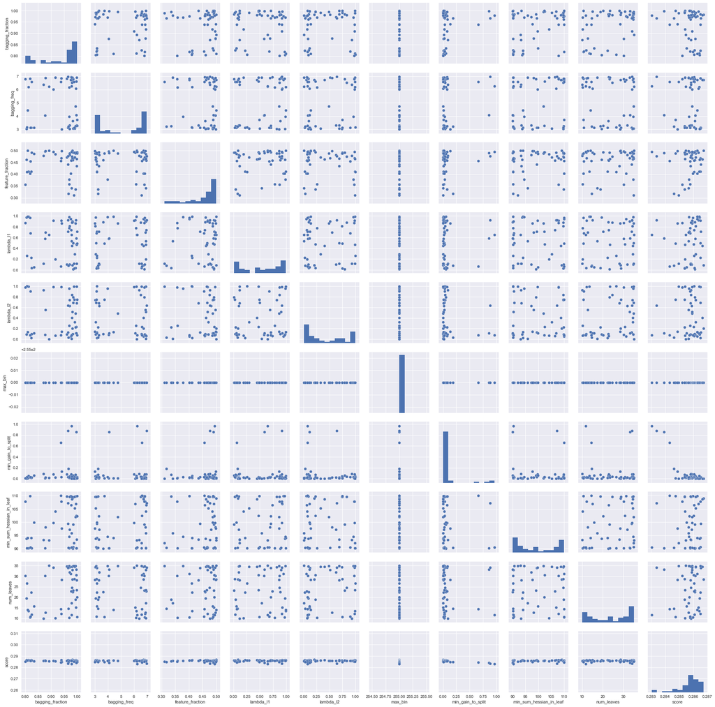

```python
sns.pairplot(lgb_BO_scores)
```

#### Train the model with smaller learning rate

```python
params = lgb_BO_scores.iloc[0].to_dict()
lgb_params = dict()
lgb_params['objective'] = 'binary'
lgb_params['learning_rate'] = 0.01 # Smaller learning rate


lgb_params['max_bin'] = int(params['max_bin'])
lgb_params['num_leaves'] = int(params['num_leaves'])
lgb_params['min_sum_hessian_in_leaf'] = int(params['min_sum_hessian_in_leaf'])
lgb_params['min_gain_to_split'] = params['min_gain_to_split']
lgb_params['feature_fraction'] = params['feature_fraction']
lgb_params['bagging_fraction'] = params['bagging_fraction']
lgb_params['bagging_freq'] = 1


cv_results = lgb.cv(lgb_params,
                lgb.Dataset(train_x, train_y, max_bin=lgb_params['max_bin']),
                num_boost_round=1000000,
                nfold=5,
                early_stopping_rounds=200,
                feval=gini_lgb,
                        stratified=True,
                        shuffle=True,
                verbose_eval=100
               )

cv_results = pd.DataFrame(cv_results)
best_lgb_iteration = len(cv_results)
best_lgb_score = cv_results['gini-mean'].max()

print (best_lgb_iteration, best_lgb_score)
```

```
[100]	cv_agg's gini: 0.258691 + 0.014121
[200]	cv_agg's gini: 0.260196 + 0.0153335
[300]	cv_agg's gini: 0.265125 + 0.0150856
[400]	cv_agg's gini: 0.269731 + 0.014866
[500]	cv_agg's gini: 0.275315 + 0.013843
[600]	cv_agg's gini: 0.279234 + 0.0135272
[700]	cv_agg's gini: 0.282319 + 0.0132687
[800]	cv_agg's gini: 0.284476 + 0.0128849
[900]	cv_agg's gini: 0.285573 + 0.0125279
[1000]	cv_agg's gini: 0.286454 + 0.0122563
[1100]	cv_agg's gini: 0.286986 + 0.0120248
[1200]	cv_agg's gini: 0.287245 + 0.0118437
[1300]	cv_agg's gini: 0.2875 + 0.0116071
[1400]	cv_agg's gini: 0.287534 + 0.0115249
[1500]	cv_agg's gini: 0.287537 + 0.0115325
[1600]	cv_agg's gini: 0.287581 + 0.0114456
[1700]	cv_agg's gini: 0.287469 + 0.01138
(1546, 0.28764007769983657)
```

```python
model = lgb.train(lgb_params,
                  lgb.Dataset(train_x,train_y, max_bin=lgb_params['max_bin']),
                  num_boost_round=best_lgb_iteration
                  )

preds = model.predict(test_x)

sub_df = pd.DataFrame({'id': ids, 'target': preds})
sub_df.to_csv("sub_lgb_tuned.csv", index=False)
```